# Objetivo 4: Número de vuelos y retrasos en fechas significativas en comparación a sus vísperas y otros días

2024-05-29

# 1 Preparación de datos

## 1.1 Fichero de las fechas

```r
fechas= read_excel("C:/Users/xgonh/OneDrive/2o UNI/2CUATRI/PROY II/festivos_eeuu_bueno2.xlsx")
```

Vamos a utilizar la base de datos que hemos llamado fechas, que contiene los dias festivos en los Estados Unidos de America, pero no usaremos todos los días, únicamente una selección de los más importantes.

```r
fechas = fechas[c(1, 23, 32, 35), ]
```

## 1.2 Fichero de los vuelos

A continuación vamos a cargar nuestras bases de datos de vuelos de 2021, 2022 y 2023 que usaremos posteriomente para los analisis.

```r
vuelos=read.csv("C:/Users/xgonh/OneDrive/2o UNI/2CUATRI/PROY II/vuelos_completo_limpiado1.csv")
vuelos2022=read.csv("C:/Users/xgonh/OneDrive/2o UNI/2CUATRI/PROY II/vuelos_completo_2022.csv")
vuelos2021=read.csv("C:/Users/xgonh/OneDrive/2o UNI/2CUATRI/PROY II/vuelos_completo_2021.csv")
```

## 1.3 Extracción de días festivos del 2023 a analizar

```r
fechas.fest= fechas$dia
fecha.lista= list()
for (fecha in fechas.fest){
  fecha.separada <- strsplit(fecha, ", ")[[1]]
  fecha.lista <- append(fecha.lista, fecha.separada[2])
}
print(fecha.lista)
```

```
## [[1]]
## [1] "1 Enero"
##
## [[2]]
## [1] "4 Julio"
##
## [[3]]
## [1] "23 Noviembre"
##
## [[4]]
## [1] "25 Diciembre"
```

Una vez hemos filtrado los días festivos nos hemos quedado con 4 de los festivos más importantes en los Estados Unidos de América, siendo estos Año Nuevo, el día de la Independencia, Acción de Gracias y Navidades.

# 2 Cantidad de vuelos los días festivos

## 2.1 Medias díarias los 3 años estudiados

Lo primero que haremos es calcular cual es el promedio de vuelos cada año por dia de la semana para tener un pequeño contexto de cuales son los días que menos o más vuelos deberían haber.

```r
media_vuelos_por_dia_semana <- rep(0, 7)

dias <- c("Lunes", "Martes", "Miercoles", "Jueves", "Viernes", "Sabado", "Domingo")
cant_dias <- setNames(rep(0, length(dias)), dias)
añadidos <- list()
for (i in 1:nrow(vuelos)) {
  dia_sem <- dias[vuelos$DAY_OF_WEEK[i]]
  media_vuelos_por_dia_semana[vuelos$DAY_OF_WEEK[i]] <- media_vuelos_por_dia_semana[vuelos$DAY_OF_WEEK[i]] + 1
  fecha <- sprintf("%02d-%02d-%04d", vuelos$DAY_OF_MONTH[i], vuelos$MONTH[i], 2023)
  if (fecha %in% names(añadidos)) {
  } else {
    añadidos[[fecha]] <- 1
    cant_dias[dias[vuelos$DAY_OF_WEEK[i]]] <- cant_dias[dias[vuelos$DAY_OF_WEEK[i]]] + 1
  }
}

media_vuelos_por_dia_semana_1 <- rep(0, 7)
for (i in 1:7){
  media_vuelos_por_dia_semana_1[i] <- media_vuelos_por_dia_semana[i]/cant_dias[dias[i]]
}

media_vuelos_por_dia_semana_df2023 <- data.frame(Dia_sem = dias, Num_Vuelos = media_vuelos_por_dia_semana_1)

print(media_vuelos_por_dia_semana_df2023)
```

```
##     Dia_sem Num_Vuelos
## 1     Lunes   20352.94
## 2    Martes   19137.19
## 3 Miercoles   19438.13
## 4    Jueves   20384.67
## 5   Viernes   20498.69
## 6    Sabado   17872.60
## 7   Domingo   19763.47
```

```r
media_vuelos_por_dia_semana <- rep(0, 7)

dias <- c("Lunes", "Martes", "Miercoles", "Jueves", "Viernes", "Sabado", "Domingo")
cant_dias <- setNames(rep(0, length(dias)), dias)
añadidos <- list()
for (i in 1:nrow(vuelos2022)) {
  dia_sem <- dias[vuelos2022$DAY_OF_WEEK[i]]
  media_vuelos_por_dia_semana[vuelos2022$DAY_OF_WEEK[i]] <- media_vuelos_por_dia_semana[vuelos2022$DAY_OF_WEEK[i]] + 1
  fecha <- sprintf("%02d-%02d-%04d", vuelos2022$DAY_OF_MONTH[i], vuelos2022$MONTH[i], 2022)
  if (fecha %in% names(añadidos)) {
  } else {
    añadidos[[fecha]] <- 1
    cant_dias[dias[vuelos2022$DAY_OF_WEEK[i]]] <- cant_dias[dias[vuelos2022$DAY_OF_WEEK[i]]] + 1
  }
}

media_vuelos_por_dia_semana_1 <- rep(0, 7)
for (i in 1:7){
  media_vuelos_por_dia_semana_1[i] <- media_vuelos_por_dia_semana[i]/cant_dias[dias[i]]
}

media_vuelos_por_dia_semana_df2022 <- data.frame(Dia_sem = dias, Num_Vuelos = media_vuelos_por_dia_semana_1)

print(media_vuelos_por_dia_semana_df2022)
```

```
##     Dia_sem Num_Vuelos
## 1     Lunes   19496.96
## 2    Martes   18410.33
## 3 Miercoles   18546.06
## 4    Jueves   19280.73
## 5   Viernes   19415.23
## 6    Sabado   16772.30
## 7   Domingo   19056.92
```

```r
media_vuelos_por_dia_semana <- rep(0, 7)

dias <- c("Lunes", "Martes", "Miercoles", "Jueves", "Viernes", "Sabado", "Domingo")
cant_dias <- setNames(rep(0, length(dias)), dias)
añadidos <- list()
for (i in 1:nrow(vuelos2021)) {
  dia_sem <- dias[vuelos2021$DAY_OF_WEEK[i]]
  media_vuelos_por_dia_semana[vuelos2021$DAY_OF_WEEK[i]] <- media_vuelos_por_dia_semana[vuelos2021$DAY_OF_WEEK[i]] + 1
  fecha <- sprintf("%02d-%02d-%04d", vuelos2021$DAY_OF_MONTH[i], vuelos2021$MONTH[i], 2021)
  if (fecha %in% names(añadidos)) {
  } else {
    añadidos[[fecha]] <- 1
    cant_dias[dias[vuelos2021$DAY_OF_WEEK[i]]] <- cant_dias[dias[vuelos2021$DAY_OF_WEEK[i]]] + 1
  }
}

media_vuelos_por_dia_semana_1 <- rep(0, 7)
for (i in 1:7){
  media_vuelos_por_dia_semana_1[i] <- media_vuelos_por_dia_semana[i]/cant_dias[dias[i]]
}

media_vuelos_por_dia_semana_df2021 <- data.frame(Dia_sem = dias, Num_Vuelos = media_vuelos_por_dia_semana_1)

print(media_vuelos_por_dia_semana_df2021)
```

```
##     Dia_sem Num_Vuelos
## 1     Lunes   17662.52
## 2    Martes   15880.23
## 3 Miercoles   16280.60
## 4    Jueves   17855.67
## 5   Viernes   17738.66
## 6    Sabado   15926.13
## 7   Domingo   17612.33
```

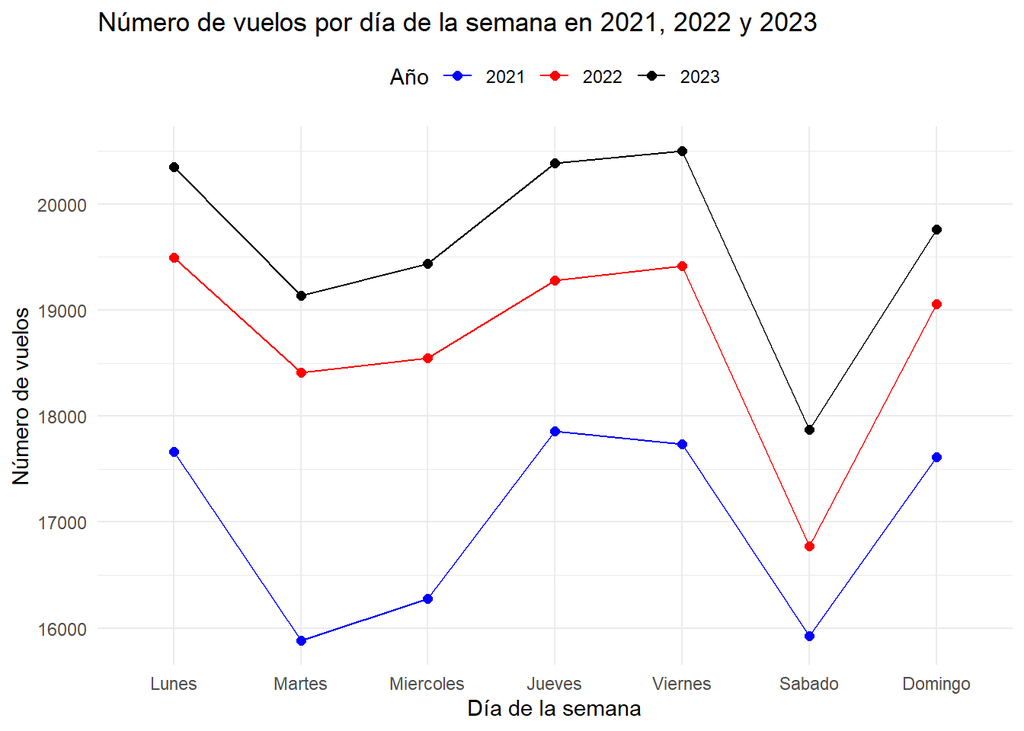

```r
media_vuelos_por_dia_semana_df2023$Color <- "2023"
media_vuelos_por_dia_semana_df2022$Color <- "2022"
media_vuelos_por_dia_semana_df2021$Color <- "2021"

vuelos_por_dia_combinado <- rbind(media_vuelos_por_dia_semana_df2023, media_vuelos_por_dia_semana_df2022, media_vuelos_por_dia_semana_df2021)

vuelos_por_dia_combinado$Dia_sem <- factor(vuelos_por_dia_combinado$Dia_sem, levels = dias)

ggplot(vuelos_por_dia_combinado, aes(x = Dia_sem, y = Num_Vuelos, color = Color)) +
  geom_line(aes(group = Color)) +
  geom_point(size = 2) +
  labs(x = "Día de la semana", y = "Número de vuelos", title = "Número de vuelos por día de la semana en 2021, 2022 y 2023") +
  scale_color_manual(values = c("2023" = "black", "2022" = "red", "2021"= "blue"), name = "Año") +
  theme_minimal() +
  theme(legend.position = "top")
```

## 2.2 Navidad y Año Nuevo

### 2.2.1 2023

Ahora veremos la cantidad de vuelos y la compararemos con los dias cercanos al festivo y con respecto al mismo día en otros meses, o incluso el día de la semana con respecto al resto de semanas del mismo mes y del año. En primer lugar observaremos la cantidad de vuelos el 1 de Enero y el 25 de Diciembre ya que están muy cercanos y representan dos de las festividades que hemos seleccionado para analizar.

```r
n_vuelos_27_dic=nrow(vuelos2022[vuelos2022$DAY_OF_MONTH==27 & vuelos2022$MONTH==12,])
n_vuelos_28_dic=nrow(vuelos2022[vuelos2022$DAY_OF_MONTH==28 & vuelos2022$MONTH==12,])
n_vuelos_29_dic=nrow(vuelos2022[vuelos2022$DAY_OF_MONTH==29 & vuelos2022$MONTH==12,])
n_vuelos_30_dic=nrow(vuelos2022[vuelos2022$DAY_OF_MONTH==30 & vuelos2022$MONTH==12,])
n_vuelos_31_dic=nrow(vuelos2022[vuelos2022$DAY_OF_MONTH==31 & vuelos2022$MONTH==12,])
n_vuelos_1_ene=nrow(vuelos[vuelos$DAY_OF_MONTH==1 & vuelos$MONTH==1,])
n_vuelos_2_ene=nrow(vuelos[vuelos$DAY_OF_MONTH==2 & vuelos$MONTH==1,])
n_vuelos_3_ene=nrow(vuelos[vuelos$DAY_OF_MONTH==3 & vuelos$MONTH==1,])
n_vuelos_4_ene=nrow(vuelos[vuelos$DAY_OF_MONTH==4 & vuelos$MONTH==1,])
n_vuelos_5_ene=nrow(vuelos[vuelos$DAY_OF_MONTH==5 & vuelos$MONTH==1,])
n_vuelos_6_ene=nrow(vuelos[vuelos$DAY_OF_MONTH==6 & vuelos$MONTH==1,])

n_vuelos_navidad= c(n_vuelos_27_dic, n_vuelos_28_dic, n_vuelos_29_dic, n_vuelos_30_dic, n_vuelos_31_dic, n_vuelos_1_ene, n_vuelos_2_ene, n_vuelos_3_ene, n_vuelos_4_ene, n_vuelos_5_ene, n_vuelos_6_ene)
```

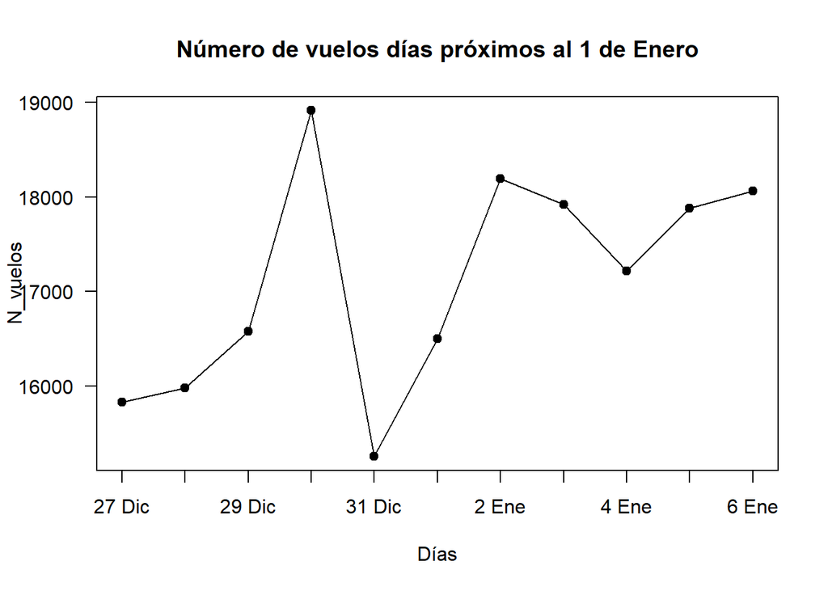

```r
plot(n_vuelos_navidad, type = "o", pch = 19, xaxt = "n", xlab = "Días", ylab = "N_vuelos", main = "Número de vuelos días próximos al 1 de Enero", las = 2)
axis(1, at = 1:11, labels = c("27 Dic", "28 Dic", "29 Dic", "30 Dic", "31 Dic","1 Ene", "2 Ene", "3 Ene", "4 Ene", "5 Ene", "6 Ene"))
```

Podemos observar que el 1 de Enero tiene un número más pequeño que la mayoría de vuelos de los días previos y posteriores, con excepción del 31 de diciembre que es el día anterior al festivo y por tanto puede tener una relación directa con este día. Lo que nos hace plantearnos la hipotesis sobre que los días de antes y después de un festivo nacional el número de vuelos es mayor que el propio dia para poder proporcionar transporte a todas aquellas personas que se movilizan con el día marcado en mente. Pero no podemos afirmar esto con unicamente este gráfico, por tanto vamos a observar como varian los vuelos durante una misma semana las semanas de antes y después, y posteriormente lo mismo pero con los meses.

Ahora vamos a observar cuales son los dias de la semana que se hacen más vuelos y cuales menos.

```r
media_vuelos_por_dia_semana <- rep(0, 7)

M <- vuelos[vuelos$MONTH == 1, ]
dias <- c("Lunes", "Martes", "Miercoles", "Jueves", "Viernes", "Sabado", "Domingo")
cant_dias <- setNames(rep(0, length(dias)), dias)
añadidos <- list()
for (i in 1:nrow(M)) {
  dia_sem <- dias[M$DAY_OF_WEEK[i]]
  media_vuelos_por_dia_semana[M$DAY_OF_WEEK[i]] <- media_vuelos_por_dia_semana[M$DAY_OF_WEEK[i]] + 1
  fecha <- sprintf("%02d-%02d-%04d", M$DAY_OF_MONTH[i], 1, 2023)
  if (fecha %in% names(añadidos)) {
  } else {
    añadidos[[fecha]] <- 1
    cant_dias[dias[M$DAY_OF_WEEK[i]]] <- cant_dias[dias[M$DAY_OF_WEEK[i]]] + 1
  }
}

M22 <- vuelos2022[vuelos2022$MONTH == 12, ]
for (i in 1:nrow(M22)) {
  dia_sem <- dias[M22$DAY_OF_WEEK[i]]
  media_vuelos_por_dia_semana[M22$DAY_OF_WEEK[i]] <- media_vuelos_por_dia_semana[M22$DAY_OF_WEEK[i]] + 1
  fecha <- sprintf("%02d-%02d-%04d", M22$DAY_OF_MONTH[i], 12, 2022)
  if (fecha %in% names(añadidos)) {
  } else {
    añadidos[[fecha]] <- 1
    cant_dias[dias[M22$DAY_OF_WEEK[i]]] <- cant_dias[dias[M22$DAY_OF_WEEK[i]]] + 1
  }
}
media_vuelos_por_dia_semana_1 <- rep(0, 7)
for (i in 1:7){
  media_vuelos_por_dia_semana_1[i] <- media_vuelos_por_dia_semana[i]/cant_dias[dias[i]]
}

media_vuelos_por_dia_semana_df <- data.frame(Dia_sem = dias, Num_Vuelos = media_vuelos_por_dia_semana_1)

print(media_vuelos_por_dia_semana_df)
```

```
##     Dia_sem Num_Vuelos
## 1     Lunes   18538.33
## 2    Martes   17664.67
## 3 Miercoles   17728.50
## 4    Jueves   18652.00
## 5   Viernes   18691.67
## 6    Sabado   15949.22
## 7   Domingo   17955.00
```

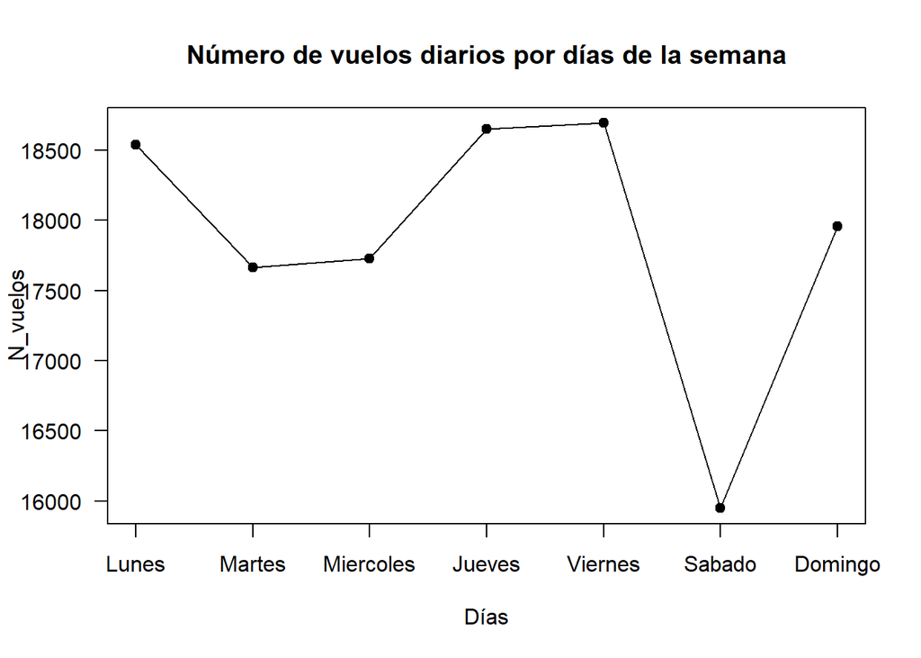

```r
plot(media_vuelos_por_dia_semana_1, type = "o", pch = 19, xaxt = "n", xlab = "Días", ylab = "N_vuelos", main = "Número de vuelos diarios por días de la semana", las = 2)
axis(1, at = 1:7, labels = c("Lunes", "Martes", "Miercoles", "Jueves", "Viernes","Sabado", "Domingo"))
```

Tras realizar este gráfico observamos durante estos dos meses cual es la media de vuelos por día de la semana, lo que nos permite observar con mayor certeza si el día festivo que estamos analizando cumple que se disminuya considerablemente la cantidad de vuelos con respecto al resto de los días cercanos y con respecto al mismo día de la semana que es.

```r
print(dias[vuelos[vuelos$DAY_OF_MONTH == 1 & vuelos$MONTH == 1, ]$DAY_OF_WEEK[1]])
```

```
## [1] "Domingo"
```

Vemos que el 1 de Enero es domingo que no es el día que tiene ni más ni menos media de número de vuelos, pero el día del festivo observamos como la cifra baja unos 2000 vuelos, siendo esta una cifra bastante significativa. Además observando el 31 de Diciembre, que es el día previo y como habiamos visto anteriormente tenia un menor número de vuelos que el propio festivo, sabemos que es sábado y que es el día de la semana que tiene un número menor de vuelos de toda la semana, pero aun así su cifra baja unos 1000 vuelos lo que sigue haciendonos pensar que podría estar relacionado el día anterior a los festivos tambíen y que estos tengan una cantidad de vuelos menor a la que deberían. Pese a todo tenemos que comprobarlo con los siguientes festivos que tenemos ya que el 31 de Diciembre es Noche Vieja, que tambíen es un día importante y esa puede ser la causa de su bajada y no que el día siguiente sea Año Nuevo.

Ahora comprobaremos si succede lo mismo con el 25 de Diciembre.

```r
n_vuelos_20_dic=nrow(vuelos2022[vuelos2022$DAY_OF_MONTH==20 & vuelos2022$MONTH==12,])
n_vuelos_21_dic=nrow(vuelos2022[vuelos2022$DAY_OF_MONTH==21 & vuelos2022$MONTH==12,])
n_vuelos_22_dic=nrow(vuelos2022[vuelos2022$DAY_OF_MONTH==22 & vuelos2022$MONTH==12,])
n_vuelos_23_dic=nrow(vuelos2022[vuelos2022$DAY_OF_MONTH==23 & vuelos2022$MONTH==12,])
n_vuelos_24_dic=nrow(vuelos2022[vuelos2022$DAY_OF_MONTH==24 & vuelos2022$MONTH==12,])
n_vuelos_25_dic=nrow(vuelos2022[vuelos2022$DAY_OF_MONTH==25 & vuelos2022$MONTH==12,])
n_vuelos_26_dic=nrow(vuelos2022[vuelos2022$DAY_OF_MONTH==26 & vuelos2022$MONTH==12,])



n_vuelos_navidad= c(n_vuelos_20_dic, n_vuelos_21_dic, n_vuelos_22_dic, n_vuelos_23_dic, n_vuelos_24_dic, n_vuelos_25_dic, n_vuelos_26_dic, n_vuelos_27_dic, n_vuelos_28_dic, n_vuelos_29_dic, n_vuelos_30_dic)
```

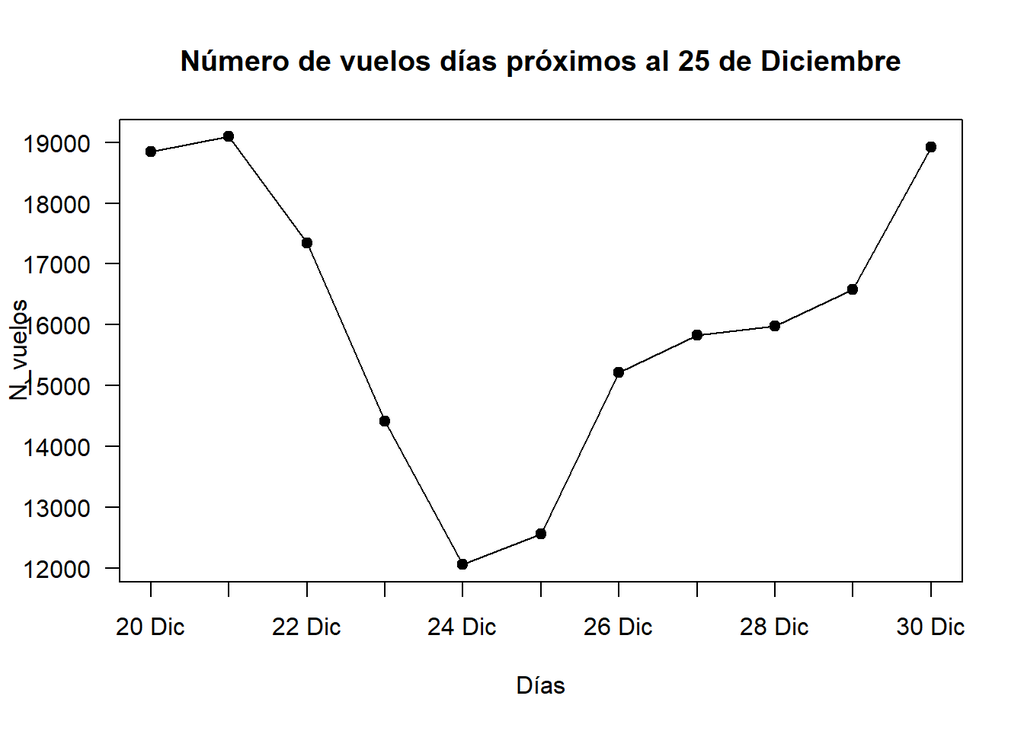

```r
plot(n_vuelos_navidad, type = "o", pch = 19, xaxt = "n", xlab = "Días", ylab = "N_vuelos", main = "Número de vuelos días próximos al 25 de Diciembre", las = 2)
axis(1, at = 1:11, labels = c("20 Dic", "21 Dic", "22 Dic", "23 Dic", "24 Dic","25 Dic", "26 Dic", "27 Dic", "28 Dic", "29 Dic", "30 Dic"))
```

```r
print(dias[vuelos2022[vuelos2022$DAY_OF_MONTH == 25 & vuelos2022$MONTH == 12, ]$DAY_OF_WEEK[1]])
```

```
## [1] "Domingo"
```

En esta ocasión sucede exactamente lo mismo que hemos visto con el 1 de Enero, el 25 de Diciembre tiene un menor número de vuelos con respecto a la mayoría de días previos y posteriores a excepción nuevamente del día previo, pero como el propio 24 de Diciembre es Noche Buena, es decir, otro día importante seguimos sin saber si puede estar relacionado con la festividad que analizamos o no. Además de que el 25 de Diciembre es también domingo por ello nuestras conclusiones respecto al día de la semana son idénticas a las anteriores.

Para observarlo de una mejor forma vamos a realizar otro grafico de lineas donde veamos como evolucionan la cantidad de vuelos desde el inicio de Diciembre del 2022 hasta final de Enero del 2023.

```r
vuelos_por_dia <- list()
V23E= vuelos[vuelos$MONTH==1,]
for (i in 1:nrow(V23E)) {
  dia <- V23E$DAY_OF_MONTH[i]
  mes <- 1
  año <- 2023
  fecha <- sprintf("%02d-%02d-%04d", dia, mes, año)
  if (fecha %in% names(vuelos_por_dia)) {
    vuelos_por_dia[[fecha]] <- vuelos_por_dia[[fecha]] + 1
  } else {
    vuelos_por_dia[[fecha]] <- 1
  }
}
V22D= vuelos2022[vuelos2022$MONTH==12,]
for (i in 1:nrow(V22D)) {
  dia <- V22D$DAY_OF_MONTH[i]
  mes <- 12
  año <- 2022
  fecha <- sprintf("%02d-%02d-%04d", dia, mes, año)
  if (fecha %in% names(vuelos_por_dia)) {
    vuelos_por_dia[[fecha]] <- vuelos_por_dia[[fecha]] + 1
  } else {
    vuelos_por_dia[[fecha]] <- 1
  }
}

vuelos_por_dia_df <- data.frame(Dia = as.Date(names(vuelos_por_dia),format = "%d-%m-%Y"), Num_Vuelos = unlist(vuelos_por_dia))

print(vuelos_por_dia_df)
```

```
##                   Dia Num_Vuelos
## 20-01-2023 2023-01-20      19597
## 28-01-2023 2023-01-28      16171
## 13-01-2023 2023-01-13      19489
## 11-01-2023 2023-01-11      17054
## 06-01-2023 2023-01-06      18064
## 21-01-2023 2023-01-21      16367
## 01-01-2023 2023-01-01      16499
## 05-01-2023 2023-01-05      17880
## 25-01-2023 2023-01-25      17856
## 26-01-2023 2023-01-26      19570
## 19-01-2023 2023-01-19      19439
## 18-01-2023 2023-01-18      17905
## 17-01-2023 2023-01-17      17973
## 27-01-2023 2023-01-27      19545
## 12-01-2023 2023-01-12      19362
## 24-01-2023 2023-01-24      17960
## 14-01-2023 2023-01-14      15797
## 09-01-2023 2023-01-09      19239
## 07-01-2023 2023-01-07      16649
## 03-01-2023 2023-01-03      17923
## 23-01-2023 2023-01-23      19070
## 22-01-2023 2023-01-22      19102
## 10-01-2023 2023-01-10      17924
## 04-01-2023 2023-01-04      17216
## 31-01-2023 2023-01-31      16340
## 29-01-2023 2023-01-29      19023
## 16-01-2023 2023-01-16      19135
## 08-01-2023 2023-01-08      18872
## 30-01-2023 2023-01-30      18159
## 15-01-2023 2023-01-15      17991
## 02-01-2023 2023-01-02      18194
## 01-12-2022 2022-12-01      19067
## 02-12-2022 2022-12-02      19179
## 03-12-2022 2022-12-03      16742
## 04-12-2022 2022-12-04      19209
## 05-12-2022 2022-12-05      19329
## 06-12-2022 2022-12-06      18300
## 07-12-2022 2022-12-07      18449
## 08-12-2022 2022-12-08      19311
```

[output cut: 8 more lines]

```
## 17-12-2022 2022-12-17      17674
## 18-12-2022 2022-12-18      19253
## 19-12-2022 2022-12-19      19318
## 20-12-2022 2022-12-20      18839
## 21-12-2022 2022-12-21      19090
## 22-12-2022 2022-12-22      17339
## 23-12-2022 2022-12-23      14413
## 24-12-2022 2022-12-24      12062
## 25-12-2022 2022-12-25      12559
## 26-12-2022 2022-12-26      15218
## 27-12-2022 2022-12-27      15827
## 28-12-2022 2022-12-28      15981
## 29-12-2022 2022-12-29      16577
## 30-12-2022 2022-12-30      18914
## 31-12-2022 2022-12-31      15256
```

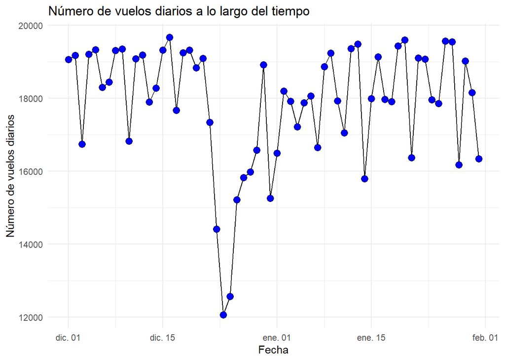

```r
ggplot(vuelos_por_dia_df, aes(x = Dia, y = Num_Vuelos)) +
  geom_line() +
  geom_point(shape = 21, size = 3, fill = "blue") +
  labs(x = "Fecha", y = "Número de vuelos diarios", title = "Número de vuelos diarios a lo largo del tiempo") +
  theme_minimal()
```

Aquí vemos como nuestra hipotesis de que el festivo tiene un número menor de vuelos se cumple muy claramente en Diciembre pero en enero no está tan claro ya que hay algunos días que tienen valores similares o cercanos al de nuestras fechas marcadas. Vamos a comprobar si esto es debido a que en enero la cantidad de vuelos es menor que en diciembre de forma general y si esto se cumple podríamos dar como válida nuestra sospecha. Teniendo en cuenta que estos días cercanos a nuestros vuelos no tienen porque ser el mismo día de la semana, y como sabemos con los gráficos anteriores hay una gran diferencia entre unos y otros.

Para ello vamos a representar la cantidad de vuelos por meses de 2022 y 2023, y vamos a observar que sucede.

```r
vuelos_por_mes <- list()
for (i in 1:nrow(vuelos)) {
  dia <- vuelos$DAY_OF_MONTH[i]
  mes <- vuelos$MONTH[i]
  año <- 2023
  fecha <- sprintf("%02d-%04d", mes, año)
  if (fecha %in% names(vuelos_por_mes)) {
    vuelos_por_mes[[fecha]] <- vuelos_por_mes[[fecha]] + 1
  } else {
    vuelos_por_mes[[fecha]] <- 1
  }
}

vuelos_por_mes_df <- data.frame(Mes = factor(names(vuelos_por_mes), levels = sprintf("%02d-%04d", 1:12, rep(2023, 12)), labels = month.abb), Num_Vuelos = unlist(vuelos_por_mes))

print(vuelos_por_mes_df)
```

```
##         Mes Num_Vuelos
## 04-2023 Apr     584624
## 12-2023 Dec     602501
## 01-2023 Jan     561365
## 03-2023 Mar     606915
## 08-2023 Aug     628954
## 11-2023 Nov     598381
## 02-2023 Feb     525485
## 10-2023 Oct     632474
## 09-2023 Sep     595744
## 06-2023 Jun     598357
## 07-2023 Jul     620780
## 05-2023 May     611464
```

```r
vuelos_por_mes2 <- list()
for (i in 1:nrow(vuelos2022)) {
  dia <- vuelos2022$DAY_OF_MONTH[i]
  mes <- vuelos2022$MONTH[i]
  año <- 2022
  fecha <- sprintf("%02d-%04d", mes, año)
  if (fecha %in% names(vuelos_por_mes2)) {
    vuelos_por_mes2[[fecha]] <- vuelos_por_mes2[[fecha]] + 1
  } else {
    vuelos_por_mes2[[fecha]] <- 1
  }
}

vuelos_por_mes2_df <- data.frame(Mes = factor(names(vuelos_por_mes2), levels = sprintf("%02d-%04d", 1:12, rep(2022, 12)), labels = month.abb), Num_Vuelos = unlist(vuelos_por_mes2))
print(vuelos_por_mes2_df)
```

```
##         Mes Num_Vuelos
## 01-2022 Jan     528452
## 02-2022 Feb     496835
## 03-2022 Mar     581758
## 04-2022 Apr     567248
## 05-2022 May     591360
## 06-2022 Jun     584201
## 07-2022 Jul     607969
## 08-2022 Aug     598799
## 09-2022 Sep     571701
## 10-2022 Oct     590581
## 11-2022 Nov     561231
## 12-2022 Dec     547521
```

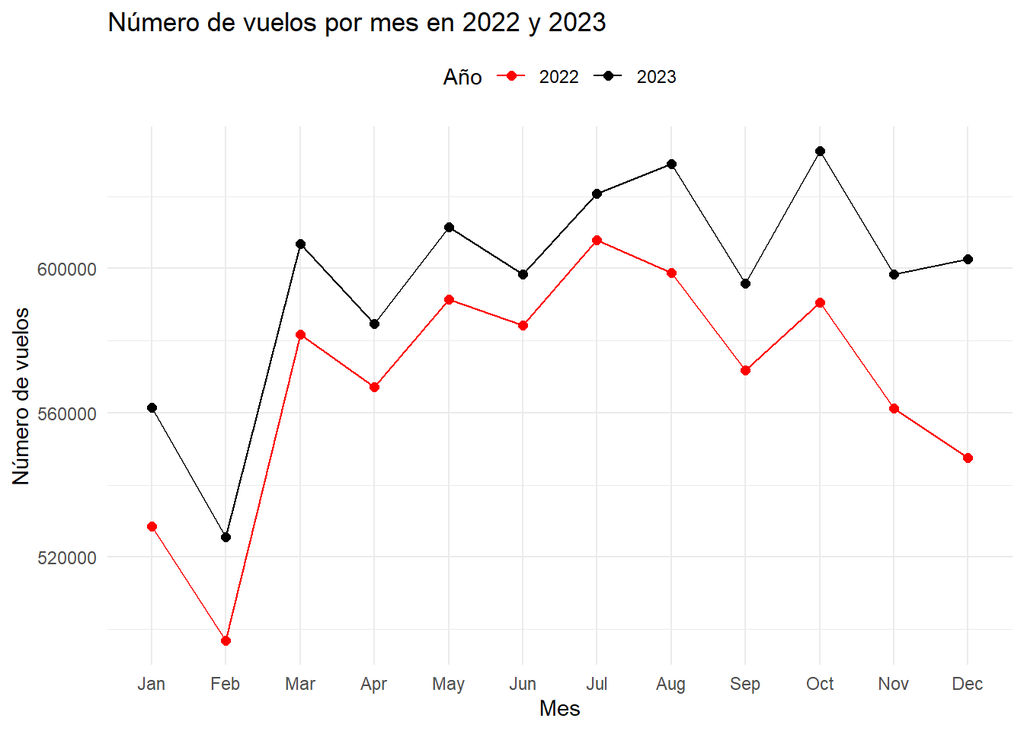

```r
vuelos_por_mes_df$Color <- "2023"
vuelos_por_mes2_df$Color <- "2022"

vuelos_por_mes_combinado <- rbind(vuelos_por_mes_df, vuelos_por_mes2_df)

vuelos_por_mes_combinado$Mes <- factor(vuelos_por_mes_combinado$Mes, levels = month.abb)

ggplot(vuelos_por_mes_combinado, aes(x = Mes, y = Num_Vuelos, color = Color)) +
  geom_line(aes(group = Color)) +
  geom_point(size = 2) +
  labs(x = "Mes", y = "Número de vuelos", title = "Número de vuelos por mes en 2022 y 2023") +
  scale_color_manual(values = c("2023" = "black", "2022" = "red"), name = "Año") +
  theme_minimal() +
  theme(legend.position = "top")
```

### 2.2.2 2022

Una vez hemos analizado estos dos festivos observamos como no podemos concluir por afirmativas ninguna de nuestras hipotesis por ello vamos a comprobar si pasa lo mismo con las misma fechas pero en el 2022 y en el 2021.

```r
n_vuelos_27_dic=nrow(vuelos2021[vuelos2021$DAY_OF_MONTH==27 & vuelos2021$MONTH==12,])
n_vuelos_28_dic=nrow(vuelos2021[vuelos2021$DAY_OF_MONTH==28 & vuelos2021$MONTH==12,])
n_vuelos_29_dic=nrow(vuelos2021[vuelos2021$DAY_OF_MONTH==29 & vuelos2021$MONTH==12,])
n_vuelos_30_dic=nrow(vuelos2021[vuelos2021$DAY_OF_MONTH==30 & vuelos2021$MONTH==12,])
n_vuelos_31_dic=nrow(vuelos2021[vuelos2021$DAY_OF_MONTH==31 & vuelos2021$MONTH==12,])
n_vuelos_1_ene=nrow(vuelos2022[vuelos2022$DAY_OF_MONTH==1 & vuelos2022$MONTH==1,])
n_vuelos_2_ene=nrow(vuelos2022[vuelos2022$DAY_OF_MONTH==2 & vuelos2022$MONTH==1,])
n_vuelos_3_ene=nrow(vuelos2022[vuelos2022$DAY_OF_MONTH==3 & vuelos2022$MONTH==1,])
n_vuelos_4_ene=nrow(vuelos2022[vuelos2022$DAY_OF_MONTH==4 & vuelos2022$MONTH==1,])
n_vuelos_5_ene=nrow(vuelos2022[vuelos2022$DAY_OF_MONTH==5 & vuelos2022$MONTH==1,])
n_vuelos_6_ene=nrow(vuelos2022[vuelos2022$DAY_OF_MONTH==6 & vuelos2022$MONTH==1,])

n_vuelos_navidad2= c(n_vuelos_27_dic, n_vuelos_28_dic, n_vuelos_29_dic, n_vuelos_30_dic, n_vuelos_31_dic, n_vuelos_1_ene, n_vuelos_2_ene, n_vuelos_3_ene, n_vuelos_4_ene, n_vuelos_5_ene, n_vuelos_6_ene)
```

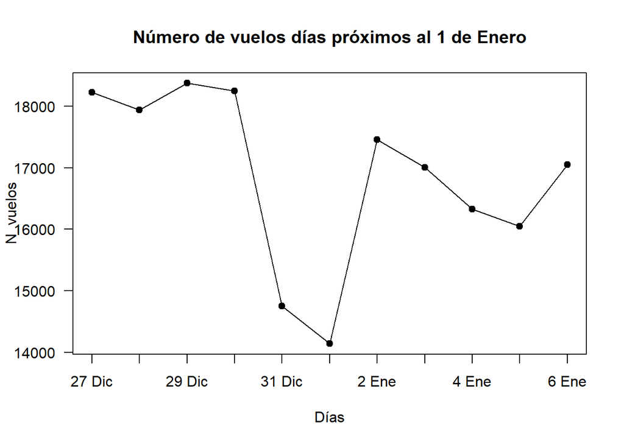

```r
plot(n_vuelos_navidad2, type = "o", pch = 19, xaxt = "n", xlab = "Días", ylab = "N_vuelos", main = "Número de vuelos días próximos al 1 de Enero", las = 2)
axis(1, at = 1:11, labels = c("27 Dic", "28 Dic", "29 Dic", "30 Dic", "31 Dic","1 Ene", "2 Ene", "3 Ene", "4 Ene", "5 Ene", "6 Ene"))
```

Como observamos vemos que pasa algo muy similar a lo que nos había dado mirando Diciembre de 2022 y Enero de 2023 con la diferencia que vemos como en Enero parece que hay una cantidad de vuelos diaria menor, pero como no podemos comprobarlo con certeza vamos a verlo con los mismos gráficos utilizados anteriormente.

```r
media_vuelos_por_dia_semana <- rep(0, 7)

M22 <- vuelos2022[vuelos2022$MONTH == 1, ]
dias <- c("Lunes", "Martes", "Miercoles", "Jueves", "Viernes", "Sabado", "Domingo")
cant_dias <- setNames(rep(0, length(dias)), dias)
añadidos <- list()
for (i in 1:nrow(M22)) {
  dia_sem <- dias[M22$DAY_OF_WEEK[i]]
  media_vuelos_por_dia_semana[M22$DAY_OF_WEEK[i]] <- media_vuelos_por_dia_semana[M22$DAY_OF_WEEK[i]] + 1
  fecha <- sprintf("%02d-%02d-%04d", M22$DAY_OF_MONTH[i], 1, 2022)
  if (fecha %in% names(añadidos)) {
  } else {
    añadidos[[fecha]] <- 1
    cant_dias[dias[M22$DAY_OF_WEEK[i]]] <- cant_dias[dias[M22$DAY_OF_WEEK[i]]] + 1
  }
}

M21 <- vuelos2021[vuelos2021$MONTH == 12, ]
for (i in 1:nrow(M21)) {
  dia_sem <- dias[M21$DAY_OF_WEEK[i]]
  media_vuelos_por_dia_semana[M21$DAY_OF_WEEK[i]] <- media_vuelos_por_dia_semana[M21$DAY_OF_WEEK[i]] + 1
  fecha <- sprintf("%02d-%02d-%04d", M21$DAY_OF_MONTH[i], 12, 2022)
  if (fecha %in% names(añadidos)) {
  } else {
    añadidos[[fecha]] <- 1
    cant_dias[dias[M21$DAY_OF_WEEK[i]]] <- cant_dias[dias[M21$DAY_OF_WEEK[i]]] + 1
  }
}
media_vuelos_por_dia_semana_1 <- rep(0, 7)
for (i in 1:7){
  media_vuelos_por_dia_semana_1[i] <- media_vuelos_por_dia_semana[i]/cant_dias[dias[i]]
}

media_vuelos_por_dia_semana_df <- data.frame(Dia_sem = dias, Num_Vuelos = media_vuelos_por_dia_semana_1)

print(media_vuelos_por_dia_semana_df)
```

```
##     Dia_sem Num_Vuelos
## 1     Lunes   18432.22
## 2    Martes   17279.75
## 3 Miercoles   17743.00
## 4    Jueves   18967.44
## 5   Viernes   17992.33
## 6    Sabado   15202.44
## 7   Domingo   17994.56
```

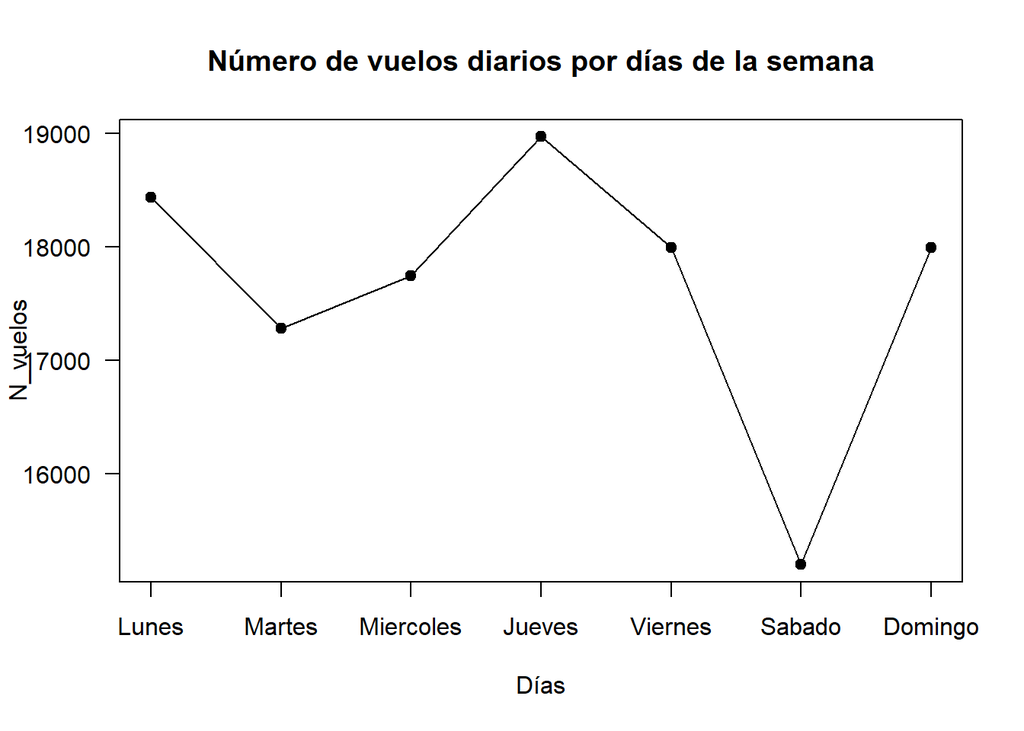

```r
plot(media_vuelos_por_dia_semana_1, type = "o", pch = 19, xaxt = "n", xlab = "Días", ylab = "N_vuelos", main = "Número de vuelos diarios por días de la semana", las = 2)
axis(1, at = 1:7, labels = c("Lunes", "Martes", "Miercoles", "Jueves", "Viernes","Sabado", "Domingo"))
```

Aqui vemos como se distribuían la cantidad de vuelos diarios durante Diciembre del 2021 y Enero del 2022, lo que nos da una mayor información al respecto

```r
print(dias[vuelos2022[vuelos2022$DAY_OF_MONTH == 1 & vuelos2022$MONTH == 1, ]$DAY_OF_WEEK[1]])
```

```
## [1] "Sabado"
```

```r
vuelos_por_dia <- list()
V22E= vuelos2022[vuelos2022$MONTH==1,]
for (i in 1:nrow(V22E)) {
  dia <- V22E$DAY_OF_MONTH[i]
  mes <- 1
  año <- 2022
  fecha <- sprintf("%02d-%02d-%04d", dia, mes, año)
  if (fecha %in% names(vuelos_por_dia)) {
    vuelos_por_dia[[fecha]] <- vuelos_por_dia[[fecha]] + 1
  } else {
    vuelos_por_dia[[fecha]] <- 1
  }
}
V21D= vuelos2021[vuelos2021$MONTH==12,]
for (i in 1:nrow(V21D)) {
  dia <- V21D$DAY_OF_MONTH[i]
  mes <- 12
  año <- 2021
  fecha <- sprintf("%02d-%02d-%04d", dia, mes, año)
  if (fecha %in% names(vuelos_por_dia)) {
    vuelos_por_dia[[fecha]] <- vuelos_por_dia[[fecha]] + 1
  } else {
    vuelos_por_dia[[fecha]] <- 1
  }
}

vuelos_por_dia_df2 <- data.frame(Dia = as.Date(names(vuelos_por_dia),format = "%d-%m-%Y"), Num_Vuelos = unlist(vuelos_por_dia))

print(vuelos_por_dia_df2)
```

```
##                   Dia Num_Vuelos
## 01-01-2022 2022-01-01      14140
## 02-01-2022 2022-01-02      17459
## 03-01-2022 2022-01-03      17002
## 04-01-2022 2022-01-04      16329
## 05-01-2022 2022-01-05      16050
## 06-01-2022 2022-01-06      17049
## 07-01-2022 2022-01-07      16744
## 08-01-2022 2022-01-08      14885
## 09-01-2022 2022-01-09      17860
## 10-01-2022 2022-01-10      17967
## 11-01-2022 2022-01-11      16500
## 12-01-2022 2022-01-12      17189
## 13-01-2022 2022-01-13      18581
## 14-01-2022 2022-01-14      18963
## 15-01-2022 2022-01-15      15118
## 16-01-2022 2022-01-16      14778
## 17-01-2022 2022-01-17      17578
## 18-01-2022 2022-01-18      16918
## 19-01-2022 2022-01-19      17305
## 20-01-2022 2022-01-20      18738
## 21-01-2022 2022-01-21      18813
## 22-01-2022 2022-01-22      15203
## 23-01-2022 2022-01-23      18606
## 24-01-2022 2022-01-24      18472
## 25-01-2022 2022-01-25      16818
## 26-01-2022 2022-01-26      17470
## 27-01-2022 2022-01-27      19209
## 28-01-2022 2022-01-28      18019
## 29-01-2022 2022-01-29      12590
## 30-01-2022 2022-01-30      17531
## 31-01-2022 2022-01-31      18568
## 01-12-2021 2021-12-01      18393
## 02-12-2021 2021-12-02      19800
## 03-12-2021 2021-12-03      19792
## 04-12-2021 2021-12-04      16376
## 05-12-2021 2021-12-05      19341
## 06-12-2021 2021-12-06      19149
## 07-12-2021 2021-12-07      17255
## 08-12-2021 2021-12-08      17886
```

[output cut: 8 more lines]

```
## 17-12-2021 2021-12-17      19966
## 18-12-2021 2021-12-18      17680
## 19-12-2021 2021-12-19      19104
## 20-12-2021 2021-12-20      19714
## 21-12-2021 2021-12-21      19335
## 22-12-2021 2021-12-22      19600
## 23-12-2021 2021-12-23      20006
## 24-12-2021 2021-12-24      15653
## 25-12-2021 2021-12-25      14763
## 26-12-2021 2021-12-26      18031
## 27-12-2021 2021-12-27      18225
## 28-12-2021 2021-12-28      17938
## 29-12-2021 2021-12-29      18374
## 30-12-2021 2021-12-30      18249
## 31-12-2021 2021-12-31      14752
```

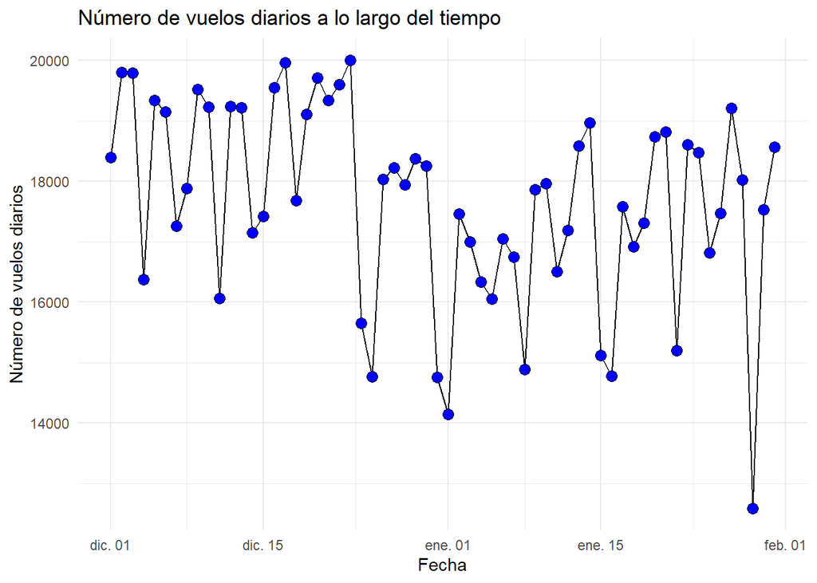

```r
ggplot(vuelos_por_dia_df2, aes(x = Dia, y = Num_Vuelos)) +
  geom_line() +
  geom_point(shape = 21, size = 3, fill = "blue") +
  labs(x = "Fecha", y = "Número de vuelos diarios", title = "Número de vuelos diarios a lo largo del tiempo") +
  theme_minimal()
```

Podemos ver que en Enero los picos de menos vuelos son más pequeños incluso que el 31 de Diciembre y 1 de Enero, pero mantiene la estructura que estabamos observando previamente. Una cosa importante que también vemos es que el 25 de diciembre tiene una cantidad menor de vuelos que el 24, lo que ya implica que algo no cuadra.

```r
print(dias[vuelos2021[vuelos2021$DAY_OF_MONTH == 25 & vuelos2021$MONTH == 12, ]$DAY_OF_WEEK[1]])
```

```
## [1] "Sabado"
```

Vemos que es sabado y que en este caso el número de vuelos si que está por debajo de su media y también nos da la sensación que parece que el número de vuelos en enero es menor que en diciembre como sucedia entre 2022 y 2023 por ello vamos a representarlo igual que antes a ver si eso nos muestra algo que nos aporte información.

```r
vuelos_por_mes <- list()
for (i in 1:nrow(vuelos2022)) {
  dia <- vuelos2022$DAY_OF_MONTH[i]
  mes <- vuelos2022$MONTH[i]
  año <- 2022
  fecha <- sprintf("%02d-%04d", mes, año)
  if (fecha %in% names(vuelos_por_mes)) {
    vuelos_por_mes[[fecha]] <- vuelos_por_mes[[fecha]] + 1
  } else {
    vuelos_por_mes[[fecha]] <- 1
  }
}

vuelos_por_mes_df <- data.frame(Mes = factor(names(vuelos_por_mes), levels = sprintf("%02d-%04d", 1:12, rep(2022, 12)), labels = month.abb), Num_Vuelos = unlist(vuelos_por_mes))

print(vuelos_por_mes_df)
```

```
##         Mes Num_Vuelos
## 01-2022 Jan     528452
## 02-2022 Feb     496835
## 03-2022 Mar     581758
## 04-2022 Apr     567248
## 05-2022 May     591360
## 06-2022 Jun     584201
## 07-2022 Jul     607969
## 08-2022 Aug     598799
## 09-2022 Sep     571701
## 10-2022 Oct     590581
## 11-2022 Nov     561231
## 12-2022 Dec     547521
```

```r
vuelos_por_mes2 <- list()
for (i in 1:nrow(vuelos2021)) {
  dia <- vuelos2021$DAY_OF_MONTH[i]
  mes <- vuelos2021$MONTH[i]
  año <- 2021
  fecha <- sprintf("%02d-%04d", mes, año)
  if (fecha %in% names(vuelos_por_mes2)) {
    vuelos_por_mes2[[fecha]] <- vuelos_por_mes2[[fecha]] + 1
  } else {
    vuelos_por_mes2[[fecha]] <- 1
  }
}

vuelos_por_mes2_df <- data.frame(Mes = factor(names(vuelos_por_mes2), levels = sprintf("%02d-%04d", 1:12, rep(2021, 12)), labels = month.abb), Num_Vuelos = unlist(vuelos_por_mes2))
print(vuelos_por_mes2_df)
```

```
##         Mes Num_Vuelos
## 01-2021 Jan     375358
## 02-2021 Feb     330167
## 03-2021 Mar     461290
## 04-2021 Apr     471498
## 05-2021 May     517827
## 06-2021 Jun     564897
## 07-2021 Jul     605852
## 08-2021 Aug     593212
## 09-2021 Sep     560361
## 10-2021 Oct     582952
## 11-2021 Nov     573270
## 12-2021 Dec     566774
```

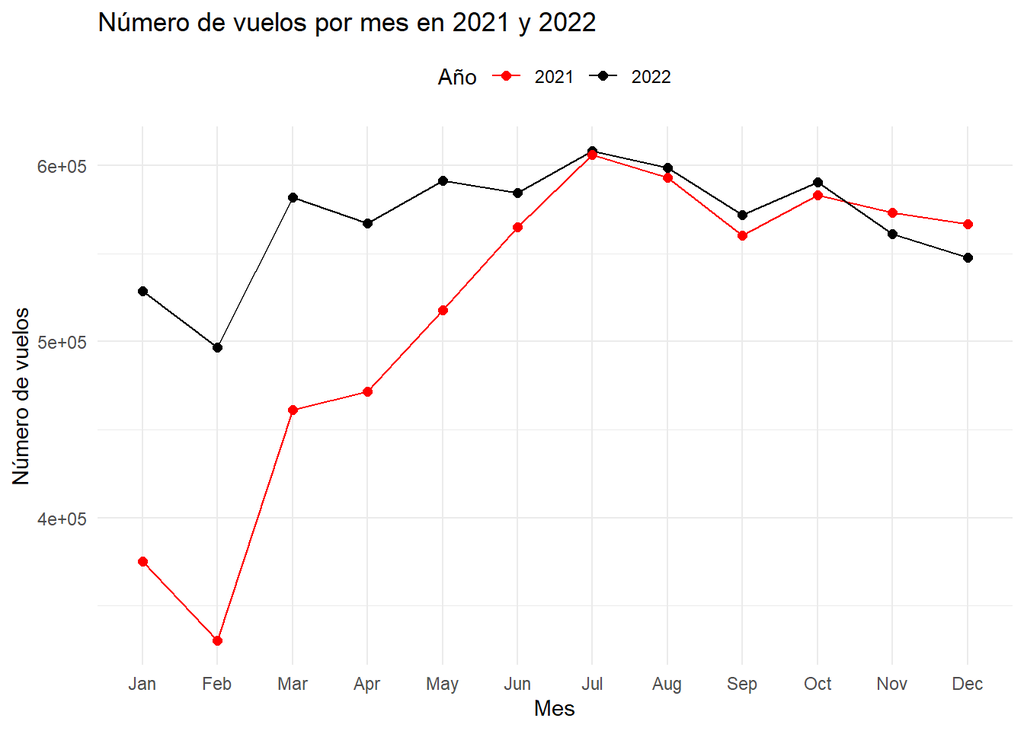

```r
vuelos_por_mes_df$Color <- "2022"
vuelos_por_mes2_df$Color <- "2021"

vuelos_por_mes_combinado <- rbind(vuelos_por_mes_df, vuelos_por_mes2_df)

vuelos_por_mes_combinado$Mes <- factor(vuelos_por_mes_combinado$Mes, levels = month.abb)

ggplot(vuelos_por_mes_combinado, aes(x = Mes, y = Num_Vuelos, color = Color)) +
  geom_line(aes(group = Color)) +
  geom_point(size = 2) +
  labs(x = "Mes", y = "Número de vuelos", title = "Número de vuelos por mes en 2021 y 2022") +
  scale_color_manual(values = c("2022" = "black", "2021" = "red"), name = "Año") +
  theme_minimal() +
  theme(legend.position = "top")
```

## 2.3 El Día de la Independencia

### 2.3.1 2023

Ahora vamos a repetir el proceso con otro día festivo, el 4 de julio, para ver si logramos concretar las dos hipótesis que arrastramos, que el número de vuelos un día festivo es menor que el resto de días cercanos o similares y si el día previo es tambíen afectado por este festivo y la cantidad de vuelos también se reduce.

```r
n_vuelos_29_junio= nrow(vuelos[vuelos$DAY_OF_MONTH==29 & vuelos$MONTH==6,])
n_vuelos_30_junio= nrow(vuelos[vuelos$DAY_OF_MONTH==30 & vuelos$MONTH==6,])
n_vuelos_1_julio= nrow(vuelos[vuelos$DAY_OF_MONTH==1 & vuelos$MONTH== 7,])
n_vuelos_2_julio= nrow(vuelos[vuelos$DAY_OF_MONTH==2 & vuelos$MONTH== 7,])
n_vuelos_3_julio= nrow(vuelos[vuelos$DAY_OF_MONTH==3 & vuelos$MONTH== 7,])
n_vuelos_4_julio= nrow(vuelos[vuelos$DAY_OF_MONTH==4 & vuelos$MONTH== 7,])
n_vuelos_5_julio= nrow(vuelos[vuelos$DAY_OF_MONTH==5 & vuelos$MONTH== 7,])
n_vuelos_6_julio= nrow(vuelos[vuelos$DAY_OF_MONTH==6 & vuelos$MONTH== 7,])
n_vuelos_7_julio= nrow(vuelos[vuelos$DAY_OF_MONTH==7 & vuelos$MONTH== 7,])
n_vuelos_8_julio= nrow(vuelos[vuelos$DAY_OF_MONTH==8 & vuelos$MONTH== 7,])
n_vuelos_9_julio= nrow(vuelos[vuelos$DAY_OF_MONTH==9 & vuelos$MONTH== 7,])

n_vuelos_4julio= c(n_vuelos_29_junio, n_vuelos_30_junio, n_vuelos_1_julio, n_vuelos_2_julio, n_vuelos_3_julio, n_vuelos_4_julio, n_vuelos_5_julio, n_vuelos_6_julio, n_vuelos_7_julio, n_vuelos_8_julio, n_vuelos_9_julio)
```

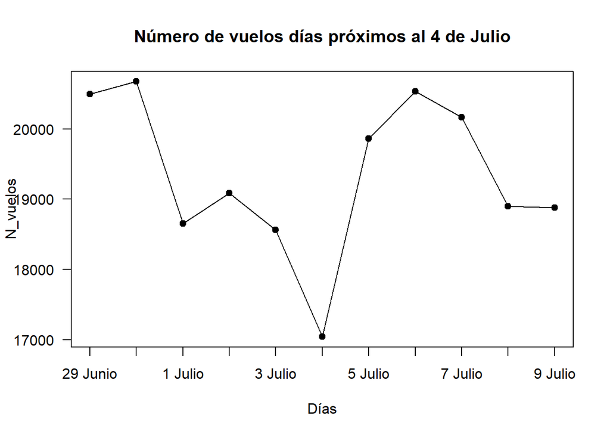

```r
plot(n_vuelos_4julio, type = "o", pch = 19, xaxt = "n", xlab = "Días", ylab = "N_vuelos", main = "Número de vuelos días próximos al 4 de Julio", las = 2)
axis(1, at = 1:11, labels = c("29 Junio", "30 Junio", "1 Julio", "2 Julio", "3 Julio", "4 Julio", "5 Julio", "6 Julio", "7 Julio", "8 Julio", "9 Julio"))
```

```r
media_vuelos_por_dia_semana <- rep(0, 7)

M <- vuelos[vuelos$MONTH == 7, ]
dias <- c("Lunes", "Martes", "Miercoles", "Jueves", "Viernes", "Sabado", "Domingo")
cant_dias <- setNames(rep(0, length(dias)), dias)
añadidos <- list()
for (i in 1:nrow(M)) {
  dia_sem <- dias[M$DAY_OF_WEEK[i]]
  media_vuelos_por_dia_semana[M$DAY_OF_WEEK[i]] <- media_vuelos_por_dia_semana[M$DAY_OF_WEEK[i]] + 1
  fecha <- sprintf("%02d-%02d-%04d", M$DAY_OF_MONTH[i], 7, 2023)
  if (fecha %in% names(añadidos)) {
  } else {
    añadidos[[fecha]] <- 1
    cant_dias[dias[M$DAY_OF_WEEK[i]]] <- cant_dias[dias[M$DAY_OF_WEEK[i]]] + 1
  }
}

media_vuelos_por_dia_semana_1 <- rep(0, 7)
for (i in 1:7){
  media_vuelos_por_dia_semana_1[i] <- media_vuelos_por_dia_semana[i]/cant_dias[dias[i]]
}

media_vuelos_por_dia_semana_df <- data.frame(Dia_sem = dias, Num_Vuelos = media_vuelos_por_dia_semana_1)

print(media_vuelos_por_dia_semana_df)
```

```
##     Dia_sem Num_Vuelos
## 1     Lunes   20700.60
## 2    Martes   19114.25
## 3 Miercoles   20284.75
## 4    Jueves   21000.75
## 5   Viernes   20670.75
## 6    Sabado   18819.60
## 7   Domingo   19779.40
```

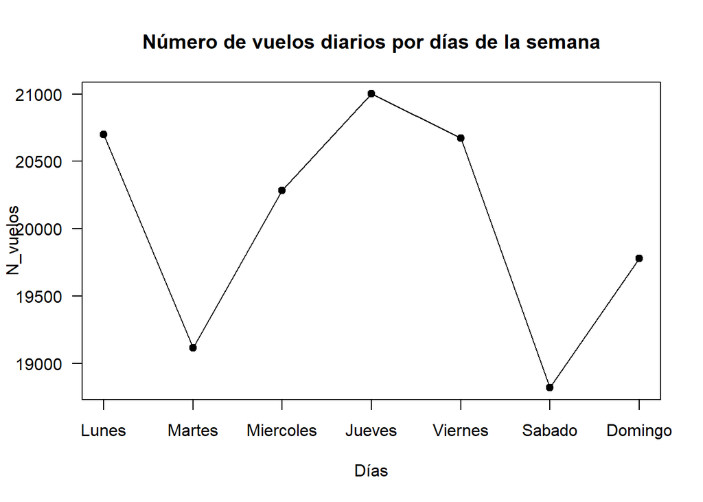

```r
plot(media_vuelos_por_dia_semana_1, type = "o", pch = 19, xaxt = "n", xlab = "Días", ylab = "N_vuelos", main = "Número de vuelos diarios por días de la semana", las = 2)
axis(1, at = 1:7, labels = c("Lunes", "Martes", "Miercoles", "Jueves", "Viernes","Sabado", "Domingo"))
```

```r
print(dias[vuelos[vuelos$DAY_OF_MONTH == 4 & vuelos$MONTH == 7, ]$DAY_OF_WEEK[1]])
```

```
## [1] "Martes"
```

```r
vuelos_por_dia <- list()
V23J= vuelos[vuelos$MONTH==7,]
for (i in 1:nrow(V23J)) {
  dia <- V23J$DAY_OF_MONTH[i]
  mes <- 7
  año <- 2023
  fecha <- sprintf("%02d-%02d-%04d", dia, mes, año)
  if (fecha %in% names(vuelos_por_dia)) {
    vuelos_por_dia[[fecha]] <- vuelos_por_dia[[fecha]] + 1
  } else {
    vuelos_por_dia[[fecha]] <- 1
  }
}
V23JN= vuelos[vuelos$MONTH==6,]
for (i in 1:nrow(V23JN)) {
  dia <- V23JN$DAY_OF_MONTH[i]
  mes <- 6
  año <- 2023
  fecha <- sprintf("%02d-%02d-%04d", dia, mes, año)
  if (fecha %in% names(vuelos_por_dia)) {
    vuelos_por_dia[[fecha]] <- vuelos_por_dia[[fecha]] + 1
  } else {
    vuelos_por_dia[[fecha]] <- 1
  }
}

vuelos_por_dia_df4 <- data.frame(Dia = as.Date(names(vuelos_por_dia),format = "%d-%m-%Y"), Num_Vuelos = unlist(vuelos_por_dia))

print(vuelos_por_dia_df4)
```

```
##                   Dia Num_Vuelos
## 18-07-2023 2023-07-18      19707
## 02-07-2023 2023-07-02      19088
## 31-07-2023 2023-07-31      21269
## 20-07-2023 2023-07-20      21156
## 21-07-2023 2023-07-21      21191
## 17-07-2023 2023-07-17      21248
## 19-07-2023 2023-07-19      20564
## 30-07-2023 2023-07-30      20702
## 14-07-2023 2023-07-14      20448
## 01-07-2023 2023-07-01      18652
## 28-07-2023 2023-07-28      20878
## 10-07-2023 2023-07-10      20977
## 23-07-2023 2023-07-23      20763
## 03-07-2023 2023-07-03      18565
## 22-07-2023 2023-07-22      19267
## 04-07-2023 2023-07-04      17043
## 24-07-2023 2023-07-24      21444
## 13-07-2023 2023-07-13      21433
## 12-07-2023 2023-07-12      20250
## 11-07-2023 2023-07-11      20193
## 07-07-2023 2023-07-07      20166
## 27-07-2023 2023-07-27      20877
## 25-07-2023 2023-07-25      19514
## 26-07-2023 2023-07-26      20462
## 05-07-2023 2023-07-05      19863
## 08-07-2023 2023-07-08      18901
## 16-07-2023 2023-07-16      19461
## 29-07-2023 2023-07-29      18432
## 09-07-2023 2023-07-09      18883
## 06-07-2023 2023-07-06      20537
## 15-07-2023 2023-07-15      18846
## 05-06-2023 2023-06-05      21007
## 07-06-2023 2023-06-07      19960
## 06-06-2023 2023-06-06      19726
## 03-06-2023 2023-06-03      18122
## 04-06-2023 2023-06-04      20392
## 02-06-2023 2023-06-02      20704
## 24-06-2023 2023-06-24      18350
## 11-06-2023 2023-06-11      20209
## 01-06-2023 2023-06-01      20655
## 29-06-2023 2023-06-29      20494
## 25-06-2023 2023-06-25      19041
## 15-06-2023 2023-06-15      20986
## 09-06-2023 2023-06-09      21114
## 08-06-2023 2023-06-08      20984
## 23-06-2023 2023-06-23      20884
## 12-06-2023 2023-06-12      20601
## 21-06-2023 2023-06-21      19787
## 27-06-2023 2023-06-27      17882
## 28-06-2023 2023-06-28      19335
## 22-06-2023 2023-06-22      20685
## 16-06-2023 2023-06-16      20664
## 10-06-2023 2023-06-10      18434
## 18-06-2023 2023-06-18      20292
## 30-06-2023 2023-06-30      20674
## 20-06-2023 2023-06-20      19653
## 19-06-2023 2023-06-19      20723
## 13-06-2023 2023-06-13      19744
## 17-06-2023 2023-06-17      18373
## 26-06-2023 2023-06-26      19062
## 14-06-2023 2023-06-14      19820
```

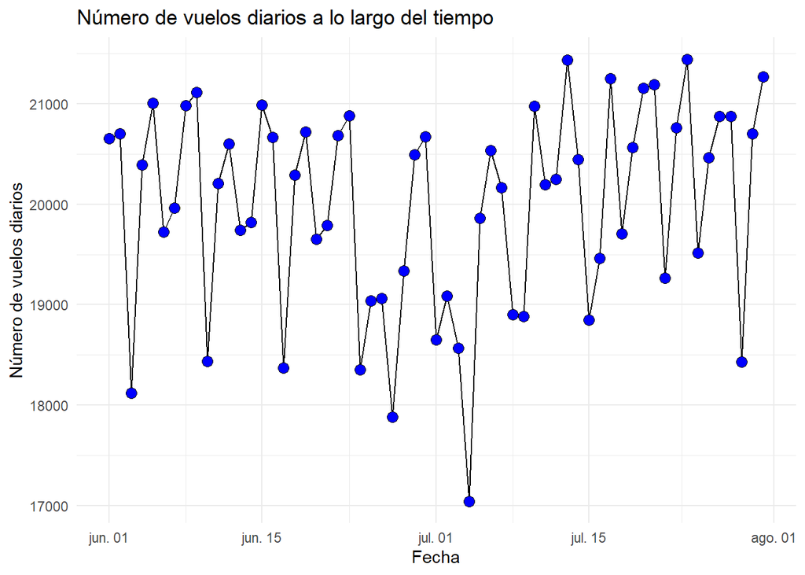

```r
ggplot(vuelos_por_dia_df4, aes(x = Dia, y = Num_Vuelos)) +
  geom_line() +
  geom_point(shape = 21, size = 3, fill = "blue") +
  labs(x = "Fecha", y = "Número de vuelos diarios", title = "Número de vuelos diarios a lo largo del tiempo") +
  theme_minimal()
```

### 2.3.2 2022

Primero vamos a ver si en los años anteriores (2022 y 2021) sucede lo mismo y si es así veremos una última fecha con la intención de demostrar nuestras hipótesis.

```r
n_vuelos_29_junio= nrow(vuelos2022[vuelos2022$DAY_OF_MONTH==29 & vuelos2022$MONTH==6,])
n_vuelos_30_junio= nrow(vuelos2022[vuelos2022$DAY_OF_MONTH==30 & vuelos2022$MONTH==6,])
n_vuelos_1_julio= nrow(vuelos2022[vuelos2022$DAY_OF_MONTH==1 & vuelos2022$MONTH== 7,])
n_vuelos_2_julio= nrow(vuelos2022[vuelos2022$DAY_OF_MONTH==2 & vuelos2022$MONTH== 7,])
n_vuelos_3_julio= nrow(vuelos2022[vuelos2022$DAY_OF_MONTH==3 & vuelos2022$MONTH== 7,])
n_vuelos_4_julio= nrow(vuelos2022[vuelos2022$DAY_OF_MONTH==4 & vuelos2022$MONTH== 7,])
n_vuelos_5_julio= nrow(vuelos2022[vuelos2022$DAY_OF_MONTH==5 & vuelos2022$MONTH== 7,])
n_vuelos_6_julio= nrow(vuelos2022[vuelos2022$DAY_OF_MONTH==6 & vuelos2022$MONTH== 7,])
n_vuelos_7_julio= nrow(vuelos2022[vuelos2022$DAY_OF_MONTH==7 & vuelos2022$MONTH== 7,])
n_vuelos_8_julio= nrow(vuelos2022[vuelos2022$DAY_OF_MONTH==8 & vuelos2022$MONTH== 7,])
n_vuelos_9_julio= nrow(vuelos2022[vuelos2022$DAY_OF_MONTH==9 & vuelos2022$MONTH== 7,])

n_vuelos_4julio= c(n_vuelos_29_junio, n_vuelos_30_junio, n_vuelos_1_julio, n_vuelos_2_julio, n_vuelos_3_julio, n_vuelos_4_julio, n_vuelos_5_julio, n_vuelos_6_julio, n_vuelos_7_julio, n_vuelos_8_julio, n_vuelos_9_julio)
```

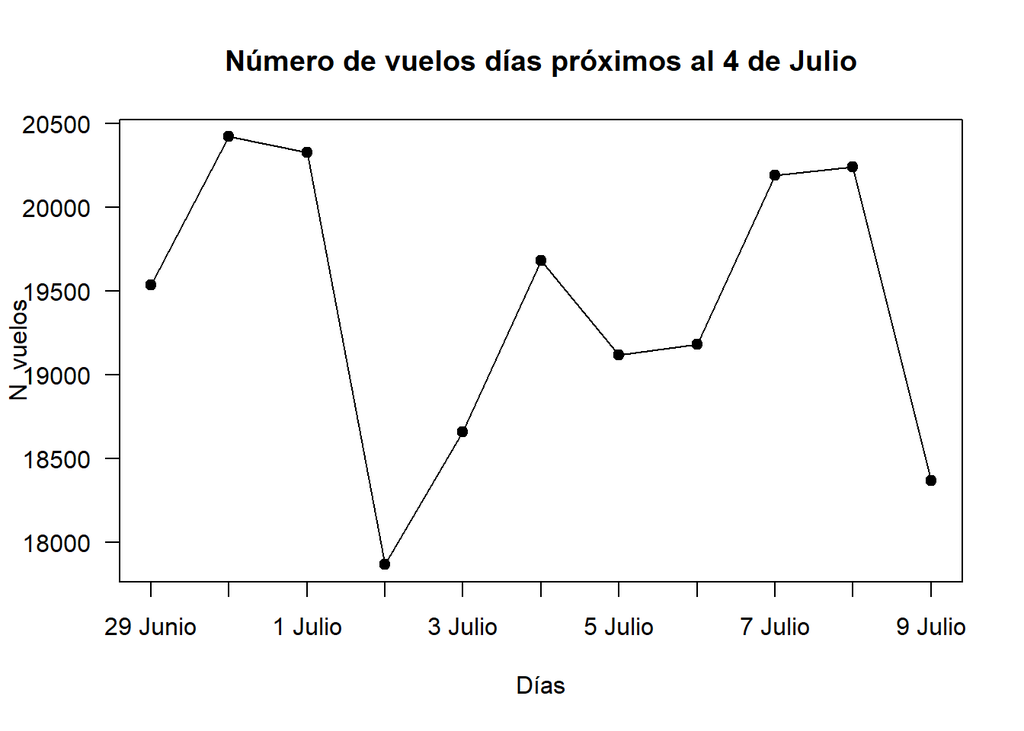

```r
plot(n_vuelos_4julio, type = "o", pch = 19, xaxt = "n", xlab = "Días", ylab = "N_vuelos", main = "Número de vuelos días próximos al 4 de Julio", las = 2)
axis(1, at = 1:11, labels = c("29 Junio", "30 Junio", "1 Julio", "2 Julio", "3 Julio", "4 Julio", "5 Julio", "6 Julio", "7 Julio", "8 Julio", "9 Julio"))
```

```r
media_vuelos_por_dia_semana <- rep(0, 7)

M <- vuelos2022[vuelos2022$MONTH == 7, ]
dias <- c("Lunes", "Martes", "Miercoles", "Jueves", "Viernes", "Sabado", "Domingo")
cant_dias <- setNames(rep(0, length(dias)), dias)
añadidos <- list()
for (i in 1:nrow(M)) {
  dia_sem <- dias[M$DAY_OF_WEEK[i]]
  media_vuelos_por_dia_semana[M$DAY_OF_WEEK[i]] <- media_vuelos_por_dia_semana[M$DAY_OF_WEEK[i]] + 1
  fecha <- sprintf("%02d-%02d-%04d", M$DAY_OF_MONTH[i], 7, 2022)
  if (fecha %in% names(añadidos)) {
  } else {
    añadidos[[fecha]] <- 1
    cant_dias[dias[M$DAY_OF_WEEK[i]]] <- cant_dias[dias[M$DAY_OF_WEEK[i]]] + 1
  }
}

media_vuelos_por_dia_semana_1 <- rep(0, 7)
for (i in 1:7){
  media_vuelos_por_dia_semana_1[i] <- media_vuelos_por_dia_semana[i]/cant_dias[dias[i]]
}

media_vuelos_por_dia_semana_df <- data.frame(Dia_sem = dias, Num_Vuelos = media_vuelos_por_dia_semana_1)

print(media_vuelos_por_dia_semana_df)
```

```
##     Dia_sem Num_Vuelos
## 1     Lunes   19961.00
## 2    Martes   19123.25
## 3 Miercoles   19546.00
## 4    Jueves   20375.50
## 5   Viernes   20462.60
## 6    Sabado   18103.00
## 7   Domingo   19823.60
```

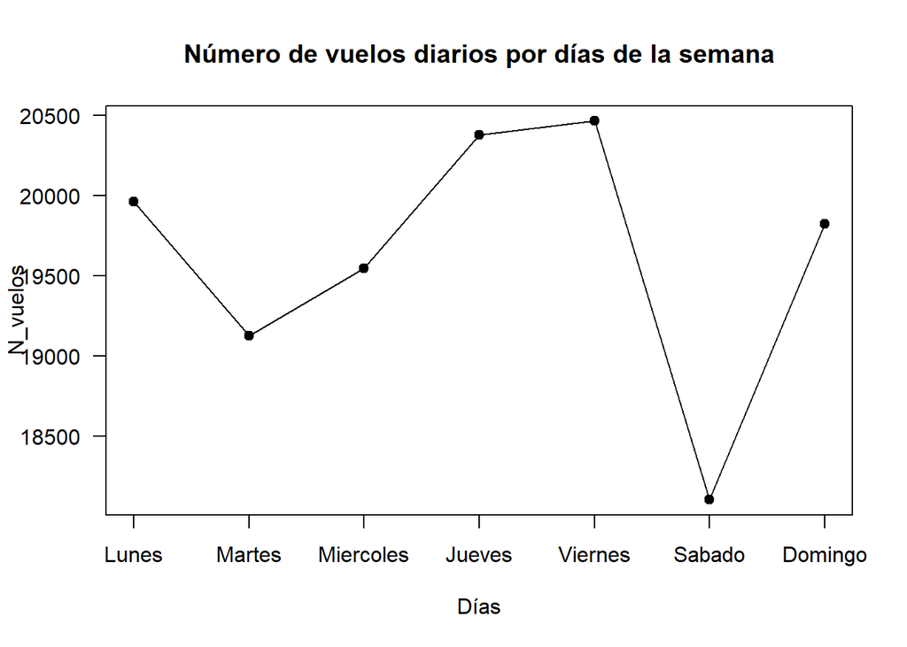

```r
plot(media_vuelos_por_dia_semana_1, type = "o", pch = 19, xaxt = "n", xlab = "Días", ylab = "N_vuelos", main = "Número de vuelos diarios por días de la semana", las = 2)
axis(1, at = 1:7, labels = c("Lunes", "Martes", "Miercoles", "Jueves", "Viernes","Sabado", "Domingo"))
```

```r
print(dias[vuelos2022[vuelos2022$DAY_OF_MONTH == 4 & vuelos2022$MONTH == 7, ]$DAY_OF_WEEK[1]])
```

```
## [1] "Lunes"
```

Durante el 2022 el 4 de Julio cae Lunes, y viendo el promedio de este día y las cifras del festivo vemos como tiene una bajada tambíen pese a no ser tan notoria como en 2023, donde si que vemos esta bajada más drastica es el día previo, con unos 1000 y pico vuelos menos, que refuerza nuestra hipotesis.

```r
vuelos_por_dia <- list()
V22J= vuelos2022[vuelos2022$MONTH==7,]
for (i in 1:nrow(V22J)) {
  dia <- V22J$DAY_OF_MONTH[i]
  mes <- 7
  año <- 2022
  fecha <- sprintf("%02d-%02d-%04d", dia, mes, año)
  if (fecha %in% names(vuelos_por_dia)) {
    vuelos_por_dia[[fecha]] <- vuelos_por_dia[[fecha]] + 1
  } else {
    vuelos_por_dia[[fecha]] <- 1
  }
}
V22JN= vuelos2022[vuelos2022$MONTH==6,]
for (i in 1:nrow(V22JN)) {
  dia <- V22JN$DAY_OF_MONTH[i]
  mes <- 6
  año <- 2022
  fecha <- sprintf("%02d-%02d-%04d", dia, mes, año)
  if (fecha %in% names(vuelos_por_dia)) {
    vuelos_por_dia[[fecha]] <- vuelos_por_dia[[fecha]] + 1
  } else {
    vuelos_por_dia[[fecha]] <- 1
  }
}

vuelos_por_dia_df4 <- data.frame(Dia = as.Date(names(vuelos_por_dia),format = "%d-%m-%Y"), Num_Vuelos = unlist(vuelos_por_dia))

print(vuelos_por_dia_df4)
```

```
##                   Dia Num_Vuelos
## 01-07-2022 2022-07-01      20331
## 02-07-2022 2022-07-02      17869
## 03-07-2022 2022-07-03      18660
## 04-07-2022 2022-07-04      19682
## 05-07-2022 2022-07-05      19119
## 06-07-2022 2022-07-06      19183
## 07-07-2022 2022-07-07      20191
## 08-07-2022 2022-07-08      20245
## 09-07-2022 2022-07-09      18370
## 10-07-2022 2022-07-10      20397
## 11-07-2022 2022-07-11      20698
## 12-07-2022 2022-07-12      19063
## 13-07-2022 2022-07-13      19690
## 14-07-2022 2022-07-14      20581
## 15-07-2022 2022-07-15      20548
## 16-07-2022 2022-07-16      18225
## 17-07-2022 2022-07-17      20212
## 18-07-2022 2022-07-18      19908
## 19-07-2022 2022-07-19      19330
## 20-07-2022 2022-07-20      19701
## 21-07-2022 2022-07-21      20488
## 22-07-2022 2022-07-22      20646
## 23-07-2022 2022-07-23      17830
## 24-07-2022 2022-07-24      19824
## 25-07-2022 2022-07-25      19556
## 26-07-2022 2022-07-26      18981
## 27-07-2022 2022-07-27      19610
## 28-07-2022 2022-07-28      20242
## 29-07-2022 2022-07-29      20543
## 30-07-2022 2022-07-30      18221
## 31-07-2022 2022-07-31      20025
## 01-06-2022 2022-06-01      18443
## 02-06-2022 2022-06-02      18752
## 03-06-2022 2022-06-03      19706
## 04-06-2022 2022-06-04      17136
## 05-06-2022 2022-06-05      20177
## 06-06-2022 2022-06-06      20469
## 07-06-2022 2022-06-07      19529
## 08-06-2022 2022-06-08      19712
## 09-06-2022 2022-06-09      20281
## 10-06-2022 2022-06-10      20413
## 11-06-2022 2022-06-11      18138
## 12-06-2022 2022-06-12      19721
## 13-06-2022 2022-06-13      20303
## 14-06-2022 2022-06-14      19343
## 15-06-2022 2022-06-15      19772
## 16-06-2022 2022-06-16      19069
## 17-06-2022 2022-06-17      19552
## 18-06-2022 2022-06-18      17790
## 19-06-2022 2022-06-19      19818
## 20-06-2022 2022-06-20      20500
## 21-06-2022 2022-06-21      19633
## 22-06-2022 2022-06-22      18823
## 23-06-2022 2022-06-23      20078
## 24-06-2022 2022-06-24      20178
## 25-06-2022 2022-06-25      17972
## 26-06-2022 2022-06-26      19827
## 27-06-2022 2022-06-27      19904
## 28-06-2022 2022-06-28      19201
## 29-06-2022 2022-06-29      19538
## 30-06-2022 2022-06-30      20423
```

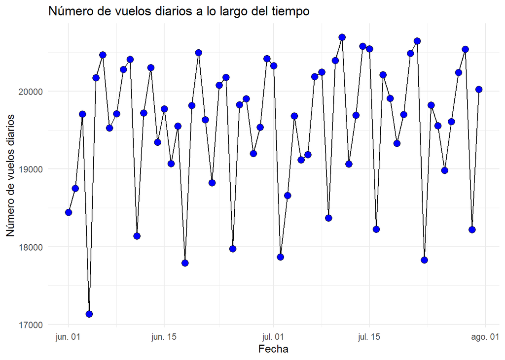

```r
ggplot(vuelos_por_dia_df4, aes(x = Dia, y = Num_Vuelos)) +
  geom_line() +
  geom_point(shape = 21, size = 3, fill = "blue") +
  labs(x = "Fecha", y = "Número de vuelos diarios", title = "Número de vuelos diarios a lo largo del tiempo") +
  theme_minimal()
```

### 2.3.3 2021

Y ahora haremos lo mismo en el 2021

```r
n_vuelos_29_junio= nrow(vuelos2021[vuelos2021$DAY_OF_MONTH==29 & vuelos2021$MONTH==6,])
n_vuelos_30_junio= nrow(vuelos2021[vuelos2021$DAY_OF_MONTH==30 & vuelos2021$MONTH==6,])
n_vuelos_1_julio= nrow(vuelos2021[vuelos2021$DAY_OF_MONTH==1 & vuelos2021$MONTH== 7,])
n_vuelos_2_julio= nrow(vuelos2021[vuelos2021$DAY_OF_MONTH==2 & vuelos2021$MONTH== 7,])
n_vuelos_3_julio= nrow(vuelos2021[vuelos2021$DAY_OF_MONTH==3 & vuelos2021$MONTH== 7,])
n_vuelos_4_julio= nrow(vuelos2021[vuelos2021$DAY_OF_MONTH==4 & vuelos2021$MONTH== 7,])
n_vuelos_5_julio= nrow(vuelos2021[vuelos2021$DAY_OF_MONTH==5 & vuelos2021$MONTH== 7,])
n_vuelos_6_julio= nrow(vuelos2021[vuelos2021$DAY_OF_MONTH==6 & vuelos2021$MONTH== 7,])
n_vuelos_7_julio= nrow(vuelos2021[vuelos2021$DAY_OF_MONTH==7 & vuelos2021$MONTH== 7,])
n_vuelos_8_julio= nrow(vuelos2021[vuelos2021$DAY_OF_MONTH==8 & vuelos2021$MONTH== 7,])
n_vuelos_9_julio= nrow(vuelos2021[vuelos2021$DAY_OF_MONTH==9 & vuelos2021$MONTH== 7,])

n_vuelos_4julio= c(n_vuelos_29_junio, n_vuelos_30_junio, n_vuelos_1_julio, n_vuelos_2_julio, n_vuelos_3_julio, n_vuelos_4_julio, n_vuelos_5_julio, n_vuelos_6_julio, n_vuelos_7_julio, n_vuelos_8_julio, n_vuelos_9_julio)
```

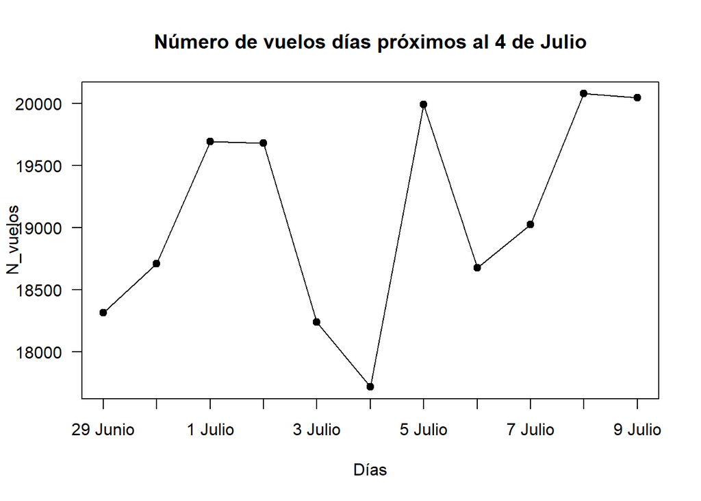

```r
plot(n_vuelos_4julio, type = "o", pch = 19, xaxt = "n", xlab = "Días", ylab = "N_vuelos", main = "Número de vuelos días próximos al 4 de Julio", las = 2)
axis(1, at = 1:11, labels = c("29 Junio", "30 Junio", "1 Julio", "2 Julio", "3 Julio", "4 Julio", "5 Julio", "6 Julio", "7 Julio", "8 Julio", "9 Julio"))
```

```r
media_vuelos_por_dia_semana <- rep(0, 7)

M <- vuelos2021[vuelos2021$MONTH == 7, ]
dias <- c("Lunes", "Martes", "Miercoles", "Jueves", "Viernes", "Sabado", "Domingo")
cant_dias <- setNames(rep(0, length(dias)), dias)
añadidos <- list()
for (i in 1:nrow(M)) {
  dia_sem <- dias[M$DAY_OF_WEEK[i]]
  media_vuelos_por_dia_semana[M$DAY_OF_WEEK[i]] <- media_vuelos_por_dia_semana[M$DAY_OF_WEEK[i]] + 1
  fecha <- sprintf("%02d-%02d-%04d", M$DAY_OF_MONTH[i], 7, 2022)
  if (fecha %in% names(añadidos)) {
  } else {
    añadidos[[fecha]] <- 1
    cant_dias[dias[M$DAY_OF_WEEK[i]]] <- cant_dias[dias[M$DAY_OF_WEEK[i]]] + 1
  }
}

media_vuelos_por_dia_semana_1 <- rep(0, 7)
for (i in 1:7){
  media_vuelos_por_dia_semana_1[i] <- media_vuelos_por_dia_semana[i]/cant_dias[dias[i]]
}

media_vuelos_por_dia_semana_df <- data.frame(Dia_sem = dias, Num_Vuelos = media_vuelos_por_dia_semana_1)

print(media_vuelos_por_dia_semana_df)
```

```
##     Dia_sem Num_Vuelos
## 1     Lunes   20070.00
## 2    Martes   18954.75
## 3 Miercoles   19285.75
## 4    Jueves   20135.40
## 5   Viernes   20196.60
## 6    Sabado   18596.80
## 7   Domingo   19491.50
```

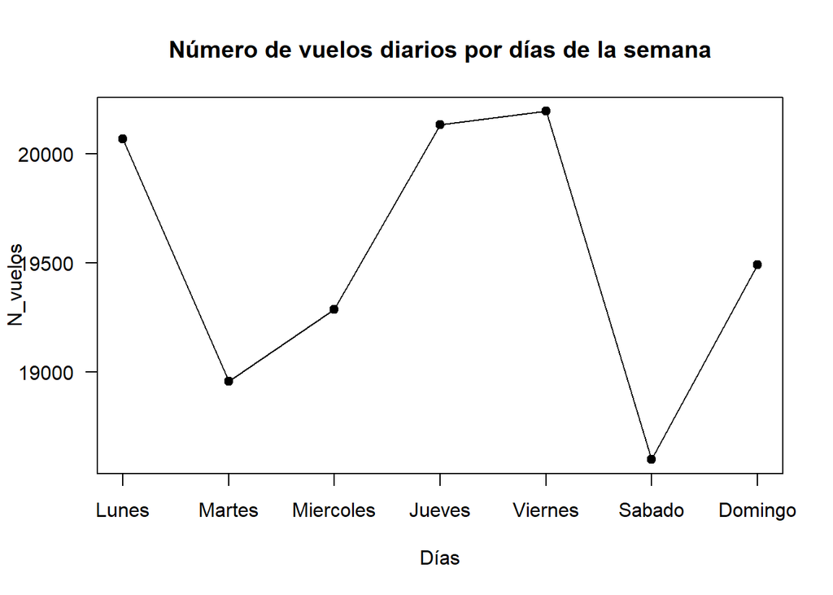

```r
plot(media_vuelos_por_dia_semana_1, type = "o", pch = 19, xaxt = "n", xlab = "Días", ylab = "N_vuelos", main = "Número de vuelos diarios por días de la semana", las = 2)
axis(1, at = 1:7, labels = c("Lunes", "Martes", "Miercoles", "Jueves", "Viernes","Sabado", "Domingo"))
```

```r
print(dias[vuelos2021[vuelos2021$DAY_OF_MONTH == 4 & vuelos2021$MONTH == 7, ]$DAY_OF_WEEK[1]])
```

```
## [1] "Domingo"
```

```r
vuelos_por_dia <- list()
V21J= vuelos2021[vuelos2021$MONTH==7,]
for (i in 1:nrow(V21J)) {
  dia <- V21J$DAY_OF_MONTH[i]
  mes <- 7
  año <- 2021
  fecha <- sprintf("%02d-%02d-%04d", dia, mes, año)
  if (fecha %in% names(vuelos_por_dia)) {
    vuelos_por_dia[[fecha]] <- vuelos_por_dia[[fecha]] + 1
  } else {
    vuelos_por_dia[[fecha]] <- 1
  }
}
V21JN= vuelos2021[vuelos2021$MONTH==6,]
for (i in 1:nrow(V21JN)) {
  dia <- V21JN$DAY_OF_MONTH[i]
  mes <- 6
  año <- 2021
  fecha <- sprintf("%02d-%02d-%04d", dia, mes, año)
  if (fecha %in% names(vuelos_por_dia)) {
    vuelos_por_dia[[fecha]] <- vuelos_por_dia[[fecha]] + 1
  } else {
    vuelos_por_dia[[fecha]] <- 1
  }
}

vuelos_por_dia_df4 <- data.frame(Dia = as.Date(names(vuelos_por_dia),format = "%d-%m-%Y"), Num_Vuelos = unlist(vuelos_por_dia))

print(vuelos_por_dia_df4)
```

```
##                   Dia Num_Vuelos
## 01-07-2021 2021-07-01      19694
## 02-07-2021 2021-07-02      19682
## 03-07-2021 2021-07-03      18241
## 04-07-2021 2021-07-04      17717
## 05-07-2021 2021-07-05      19993
## 06-07-2021 2021-07-06      18676
## 07-07-2021 2021-07-07      19026
## 08-07-2021 2021-07-08      20079
## 09-07-2021 2021-07-09      20045
## 10-07-2021 2021-07-10      18784
## 11-07-2021 2021-07-11      20051
## 12-07-2021 2021-07-12      19981
## 13-07-2021 2021-07-13      18901
## 14-07-2021 2021-07-14      19208
## 15-07-2021 2021-07-15      20276
## 16-07-2021 2021-07-16      20428
## 17-07-2021 2021-07-17      18506
## 18-07-2021 2021-07-18      20035
## 19-07-2021 2021-07-19      20160
## 20-07-2021 2021-07-20      19157
## 21-07-2021 2021-07-21      19414
## 22-07-2021 2021-07-22      20358
## 23-07-2021 2021-07-23      20415
## 24-07-2021 2021-07-24      18801
## 25-07-2021 2021-07-25      20163
## 26-07-2021 2021-07-26      20146
## 27-07-2021 2021-07-27      19085
## 28-07-2021 2021-07-28      19495
## 29-07-2021 2021-07-29      20270
## 30-07-2021 2021-07-30      20413
## 31-07-2021 2021-07-31      18652
## 01-06-2021 2021-06-01      16568
## 02-06-2021 2021-06-02      16889
## 03-06-2021 2021-06-03      18660
## 04-06-2021 2021-06-04      19149
## 05-06-2021 2021-06-05      17909
## 06-06-2021 2021-06-06      19547
## 07-06-2021 2021-06-07      19169
## 08-06-2021 2021-06-08      18013
## 09-06-2021 2021-06-09      18462
## 10-06-2021 2021-06-10      19670
## 11-06-2021 2021-06-11      19844
## 12-06-2021 2021-06-12      18246
## 13-06-2021 2021-06-13      19525
## 14-06-2021 2021-06-14      19598
## 15-06-2021 2021-06-15      17902
## 16-06-2021 2021-06-16      18478
## 17-06-2021 2021-06-17      19760
## 18-06-2021 2021-06-18      19761
## 19-06-2021 2021-06-19      18365
## 20-06-2021 2021-06-20      19644
## 21-06-2021 2021-06-21      19185
## 22-06-2021 2021-06-22      18372
## 23-06-2021 2021-06-23      18889
## 24-06-2021 2021-06-24      19646
## 25-06-2021 2021-06-25      19638
## 26-06-2021 2021-06-26      17944
## 27-06-2021 2021-06-27      19569
## 28-06-2021 2021-06-28      19468
## 29-06-2021 2021-06-29      18315
## 30-06-2021 2021-06-30      18712
```

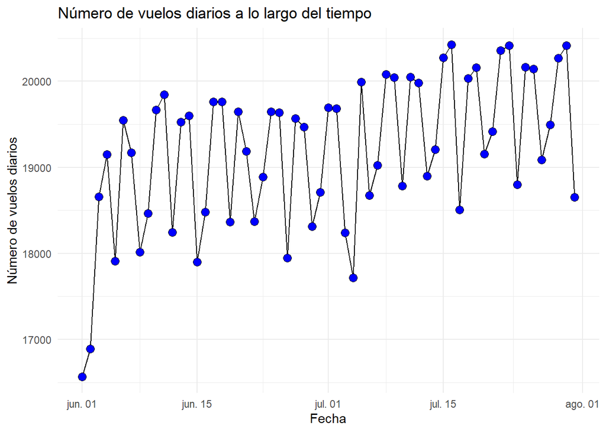

```r
ggplot(vuelos_por_dia_df4, aes(x = Dia, y = Num_Vuelos)) +
  geom_line() +
  geom_point(shape = 21, size = 3, fill = "blue") +
  labs(x = "Fecha", y = "Número de vuelos diarios", title = "Número de vuelos diarios a lo largo del tiempo") +
  theme_minimal()
```

En este caso el 4 de Julio es Domingo y vemos que con respecto al promedio de los domingos si que baja la cantidad de vuelos como venia sucediendo los años siguientes, y con respecto al día previo también hay una pequeña bajada en las cifras, pero en este caso al ver la distribución que va siguiendo el resto del mes y con el gráfico que habiamos hechos más arriba donde veiamos que durante el 2021 el número de vuelos se iba aumentando por la recuperación de la pandemia mundial, podemos pensar que también tiene una bajada influenciada por el festivo del día siguiente.

## 2.4 Día de Acción de Gracias

### 2.4.1 2023

Ahora miraremos un último festivo (accion de gracias) que teniamos en nuestra lista para ver si con ello podemos afirmar nuestras dos hiposis.

```r
n_vuelos_18_nov=nrow(vuelos[vuelos$DAY_OF_MONTH==18 & vuelos$MONTH==11,])
n_vuelos_19_nov=nrow(vuelos[vuelos$DAY_OF_MONTH==19 & vuelos$MONTH==11,])
n_vuelos_20_nov=nrow(vuelos[vuelos$DAY_OF_MONTH==20 & vuelos$MONTH==11,])
n_vuelos_21_nov=nrow(vuelos[vuelos$DAY_OF_MONTH==21 & vuelos$MONTH==11,])
n_vuelos_22_nov=nrow(vuelos[vuelos$DAY_OF_MONTH==22 & vuelos$MONTH==11,])
n_vuelos_23_nov=nrow(vuelos[vuelos$DAY_OF_MONTH==23 & vuelos$MONTH==11,])
n_vuelos_24_nov=nrow(vuelos[vuelos$DAY_OF_MONTH==24 & vuelos$MONTH==11,])
n_vuelos_25_nov=nrow(vuelos[vuelos$DAY_OF_MONTH==25 & vuelos$MONTH==11,])
n_vuelos_26_nov=nrow(vuelos[vuelos$DAY_OF_MONTH==26 & vuelos$MONTH==11,])
n_vuelos_27_nov=nrow(vuelos[vuelos$DAY_OF_MONTH==27 & vuelos$MONTH==11,])
n_vuelos_28_nov=nrow(vuelos[vuelos$DAY_OF_MONTH==28 & vuelos$MONTH==11,])

n_vuelos= c(n_vuelos_18_nov, n_vuelos_19_nov, n_vuelos_20_nov, n_vuelos_21_nov, n_vuelos_22_nov, n_vuelos_23_nov, n_vuelos_24_nov, n_vuelos_25_nov, n_vuelos_26_nov, n_vuelos_27_nov, n_vuelos_28_nov)
```

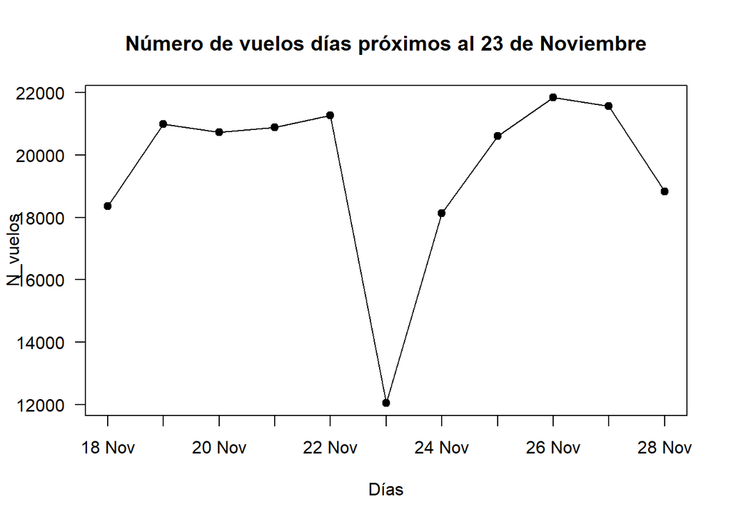

```r
plot(n_vuelos, type = "o", pch = 19, xaxt = "n", xlab = "Días", ylab = "N_vuelos", main = "Número de vuelos días próximos al 23 de Noviembre", las = 2)
axis(1, at = 1:11, labels = c("18 Nov", "19 Nov", "20 Nov", "21 Nov", "22 Nov","23 Nov", "24 Nov", "25 Nov", "26 Nov", "27 Nov", "28 Nov"))
```

```r
media_vuelos_por_dia_semana <- rep(0, 7)

M <- vuelos[vuelos$MONTH == 11, ]
dias <- c("Lunes", "Martes", "Miercoles", "Jueves", "Viernes", "Sabado", "Domingo")
cant_dias <- setNames(rep(0, length(dias)), dias)
añadidos <- list()
for (i in 1:nrow(M)) {
  dia_sem <- dias[M$DAY_OF_WEEK[i]]
  media_vuelos_por_dia_semana[M$DAY_OF_WEEK[i]] <- media_vuelos_por_dia_semana[M$DAY_OF_WEEK[i]] + 1
  fecha <- sprintf("%02d-%02d-%04d", M$DAY_OF_MONTH[i], 11, 2023)
  if (fecha %in% names(añadidos)) {
  } else {
    añadidos[[fecha]] <- 1
    cant_dias[dias[M$DAY_OF_WEEK[i]]] <- cant_dias[dias[M$DAY_OF_WEEK[i]]] + 1
  }
}
M <- vuelos[vuelos$MONTH == 12, ]
for (i in 1:nrow(M)) {
  dia_sem <- dias[M$DAY_OF_WEEK[i]]
  media_vuelos_por_dia_semana[M$DAY_OF_WEEK[i]] <- media_vuelos_por_dia_semana[M$DAY_OF_WEEK[i]] + 1
  fecha <- sprintf("%02d-%02d-%04d", M$DAY_OF_MONTH[i], 12, 2023)
  if (fecha %in% names(añadidos)) {
  } else {
    añadidos[[fecha]] <- 1
    cant_dias[dias[M$DAY_OF_WEEK[i]]] <- cant_dias[dias[M$DAY_OF_WEEK[i]]] + 1
  }
}

media_vuelos_por_dia_semana_1 <- rep(0, 7)
for (i in 1:7){
  media_vuelos_por_dia_semana_1[i] <- media_vuelos_por_dia_semana[i]/cant_dias[dias[i]]
}

media_vuelos_por_dia_semana_df <- data.frame(Dia_sem = dias, Num_Vuelos = media_vuelos_por_dia_semana_1)

print(media_vuelos_por_dia_semana_df)
```

```
##     Dia_sem Num_Vuelos
## 1     Lunes   20164.38
## 2    Martes   19459.88
## 3 Miercoles   19715.00
## 4    Jueves   19766.89
## 5   Viernes   20474.33
## 6    Sabado   18406.67
## 7   Domingo   19846.89
```

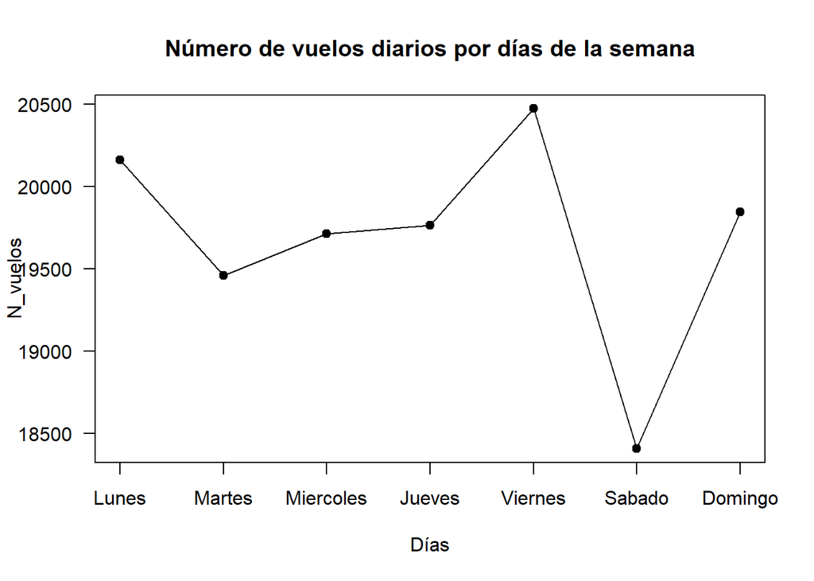

```r
plot(media_vuelos_por_dia_semana_1, type = "o", pch = 19, xaxt = "n", xlab = "Días", ylab = "N_vuelos", main = "Número de vuelos diarios por días de la semana", las = 2)
axis(1, at = 1:7, labels = c("Lunes", "Martes", "Miercoles", "Jueves", "Viernes","Sabado", "Domingo"))
```

```r
print(dias[vuelos[vuelos$DAY_OF_MONTH == 23 & vuelos$MONTH == 11, ]$DAY_OF_WEEK[1]])
```

```
## [1] "Jueves"
```

```r
vuelos_por_dia <- list()
V23E= vuelos[vuelos$MONTH==11,]
for (i in 1:nrow(V23E)) {
  dia <- V23E$DAY_OF_MONTH[i]
  mes <- 11
  año <- 2023
  fecha <- sprintf("%02d-%02d-%04d", dia, mes, año)
  if (fecha %in% names(vuelos_por_dia)) {
    vuelos_por_dia[[fecha]] <- vuelos_por_dia[[fecha]] + 1
  } else {
    vuelos_por_dia[[fecha]] <- 1
  }
}
V23E= vuelos[vuelos$MONTH==12,]
for (i in 1:nrow(V23E)) {
  dia <- V23E$DAY_OF_MONTH[i]
  mes <- 12
  año <- 2023
  fecha <- sprintf("%02d-%02d-%04d", dia, mes, año)
  if (fecha %in% names(vuelos_por_dia)) {
    vuelos_por_dia[[fecha]] <- vuelos_por_dia[[fecha]] + 1
  } else {
    vuelos_por_dia[[fecha]] <- 1
  }
}

vuelos_por_dia_df <- data.frame(Dia = as.Date(names(vuelos_por_dia),format = "%d-%m-%Y"), Num_Vuelos = unlist(vuelos_por_dia))

print(vuelos_por_dia_df)
```

```
##                   Dia Num_Vuelos
## 27-11-2023 2023-11-27      21560
## 15-11-2023 2023-11-15      19907
## 13-11-2023 2023-11-13      21011
## 24-11-2023 2023-11-24      18139
## 25-11-2023 2023-11-25      20610
## 26-11-2023 2023-11-26      21838
## 16-11-2023 2023-11-16      21076
## 10-11-2023 2023-11-10      21039
## 17-11-2023 2023-11-17      21154
## 14-11-2023 2023-11-14      19732
## 11-11-2023 2023-11-11      17868
## 28-11-2023 2023-11-28      18825
## 29-11-2023 2023-11-29      18729
## 19-11-2023 2023-11-19      20985
## 09-11-2023 2023-11-09      21098
## 22-11-2023 2023-11-22      21268
## 30-11-2023 2023-11-30      20220
## 21-11-2023 2023-11-21      20880
## 03-11-2023 2023-11-03      20967
## 20-11-2023 2023-11-20      20735
## 06-11-2023 2023-11-06      20957
## 05-11-2023 2023-11-05      20578
## 01-11-2023 2023-11-01      19579
## 23-11-2023 2023-11-23      12045
## 18-11-2023 2023-11-18      18355
## 07-11-2023 2023-11-07      19631
## 02-11-2023 2023-11-02      21023
## 04-11-2023 2023-11-04      17873
## 08-11-2023 2023-11-08      19862
## 12-11-2023 2023-11-12      20837
## 03-12-2023 2023-12-03      20132
## 22-12-2023 2023-12-22      20955
## 09-12-2023 2023-12-09      17108
## 15-12-2023 2023-12-15      20747
## 06-12-2023 2023-12-06      18763
## 04-12-2023 2023-12-04      20282
## 16-12-2023 2023-12-16      17476
## 11-12-2023 2023-12-11      20351
## 23-12-2023 2023-12-23      19635
## 01-12-2023 2023-12-01      20253
## 08-12-2023 2023-12-08      20593
## 12-12-2023 2023-12-12      18771
## 17-12-2023 2023-12-17      19641
## 14-12-2023 2023-12-14      20632
## 05-12-2023 2023-12-05      18528
## 07-12-2023 2023-12-07      20605
## 02-12-2023 2023-12-02      17122
## 21-12-2023 2023-12-21      20878
## 10-12-2023 2023-12-10      20308
## 27-12-2023 2023-12-27      20140
## 18-12-2023 2023-12-18      19316
## 30-12-2023 2023-12-30      19613
## 31-12-2023 2023-12-31      17772
## 29-12-2023 2023-12-29      20422
## 13-12-2023 2023-12-13      19038
## 20-12-2023 2023-12-20      20149
## 25-12-2023 2023-12-25      17103
## 28-12-2023 2023-12-28      20325
## 19-12-2023 2023-12-19      19144
## 26-12-2023 2023-12-26      20168
## 24-12-2023 2023-12-24      16531
```

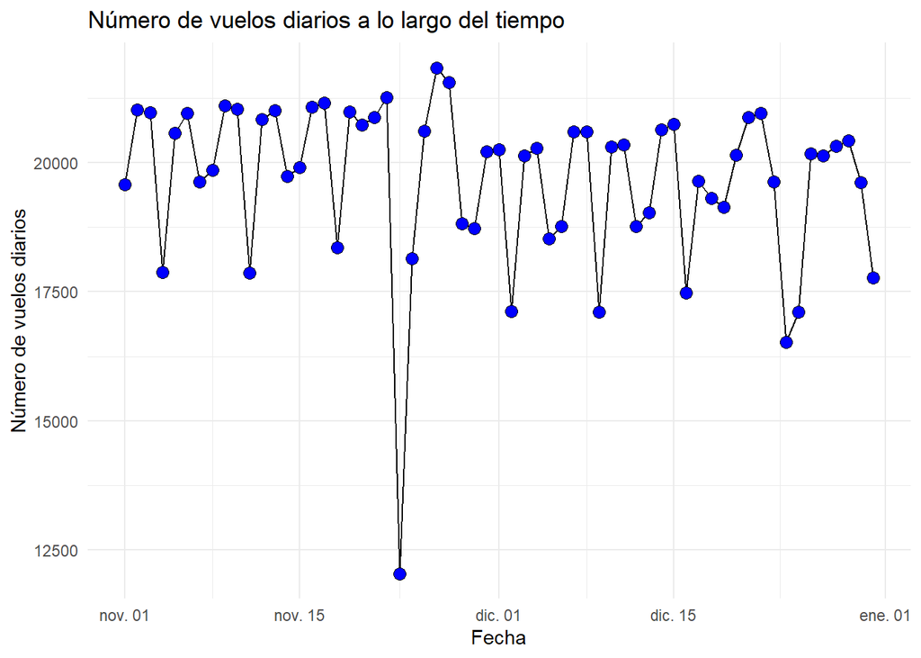

```r
ggplot(vuelos_por_dia_df, aes(x = Dia, y = Num_Vuelos)) +
  geom_line() +
  geom_point(shape = 21, size = 3, fill = "blue") +
  labs(x = "Fecha", y = "Número de vuelos diarios", title = "Número de vuelos diarios a lo largo del tiempo") +
  theme_minimal()
```

Observamos que el 23 de noviembre (accion de gracias en 2023) hay una bajada muy drástica de la cantidad de vuelos, mucho mayor que en los festivos anteriores, pero al mirar el día previo vemos como hay una cifra bastante más elevada que la media de vuelos ese día, unos 1500 vuelos más, lo que no nos cuadra con nuestra hipótesis. Vamos a ver que sucede en el 2022 y 2021, para poder detectar si es un posible dato anómalo o si se repite en el tiempo estas circunstancias.

### 2.4.2 2022

```r
n_vuelos_19_nov=nrow(vuelos2022[vuelos2022$DAY_OF_MONTH==19 & vuelos2022$MONTH==11,])
n_vuelos_20_nov=nrow(vuelos2022[vuelos2022$DAY_OF_MONTH==20 & vuelos2022$MONTH==11,])
n_vuelos_21_nov=nrow(vuelos2022[vuelos2022$DAY_OF_MONTH==21 & vuelos2022$MONTH==11,])
n_vuelos_22_nov=nrow(vuelos2022[vuelos2022$DAY_OF_MONTH==22 & vuelos2022$MONTH==11,])
n_vuelos_23_nov=nrow(vuelos2022[vuelos2022$DAY_OF_MONTH==23 & vuelos2022$MONTH==11,])
n_vuelos_24_nov=nrow(vuelos2022[vuelos2022$DAY_OF_MONTH==24 & vuelos2022$MONTH==11,])
n_vuelos_25_nov=nrow(vuelos2022[vuelos2022$DAY_OF_MONTH==25 & vuelos2022$MONTH==11,])
n_vuelos_26_nov=nrow(vuelos2022[vuelos2022$DAY_OF_MONTH==26 & vuelos2022$MONTH==11,])
n_vuelos_27_nov=nrow(vuelos2022[vuelos2022$DAY_OF_MONTH==27 & vuelos2022$MONTH==11,])
n_vuelos_28_nov=nrow(vuelos2022[vuelos2022$DAY_OF_MONTH==28 & vuelos2022$MONTH==11,])
n_vuelos_29_nov=nrow(vuelos2022[vuelos2022$DAY_OF_MONTH==29 & vuelos2022$MONTH==11,])

n_vuelos= c(n_vuelos_19_nov, n_vuelos_20_nov, n_vuelos_21_nov, n_vuelos_22_nov, n_vuelos_23_nov, n_vuelos_24_nov, n_vuelos_25_nov, n_vuelos_26_nov, n_vuelos_27_nov, n_vuelos_28_nov, n_vuelos_29_nov)
```

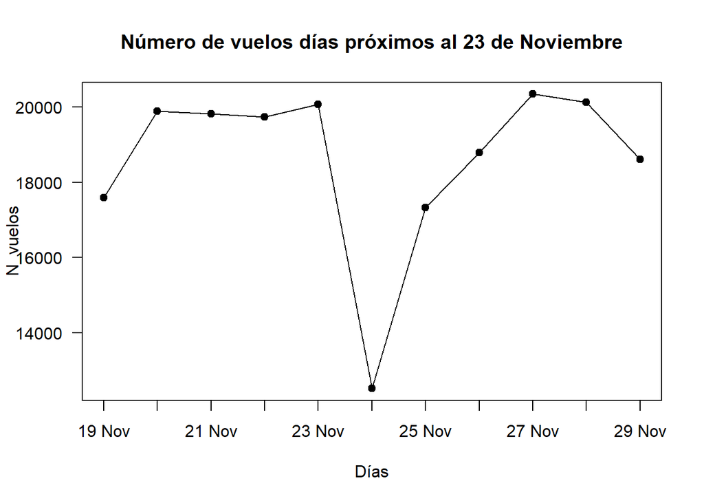

```r
plot(n_vuelos, type = "o", pch = 19, xaxt = "n", xlab = "Días", ylab = "N_vuelos", main = "Número de vuelos días próximos al 23 de Noviembre", las = 2)
axis(1, at = 1:11, labels = c("19 Nov", "20 Nov", "21 Nov", "22 Nov","23 Nov", "24 Nov", "25 Nov", "26 Nov", "27 Nov", "28 Nov", "29 Nov"))
```

```r
media_vuelos_por_dia_semana <- rep(0, 7)

M <- vuelos2022[vuelos2022$MONTH == 11, ]
dias <- c("Lunes", "Martes", "Miercoles", "Jueves", "Viernes", "Sabado", "Domingo")
cant_dias <- setNames(rep(0, length(dias)), dias)
añadidos <- list()
for (i in 1:nrow(M)) {
  dia_sem <- dias[M$DAY_OF_WEEK[i]]
  media_vuelos_por_dia_semana[M$DAY_OF_WEEK[i]] <- media_vuelos_por_dia_semana[M$DAY_OF_WEEK[i]] + 1
  fecha <- sprintf("%02d-%02d-%04d", M$DAY_OF_MONTH[i], 11, 2022)
  if (fecha %in% names(añadidos)) {
  } else {
    añadidos[[fecha]] <- 1
    cant_dias[dias[M$DAY_OF_WEEK[i]]] <- cant_dias[dias[M$DAY_OF_WEEK[i]]] + 1
  }
}
M <- vuelos2022[vuelos2022$MONTH == 12, ]
for (i in 1:nrow(M)) {
  dia_sem <- dias[M$DAY_OF_WEEK[i]]
  media_vuelos_por_dia_semana[M$DAY_OF_WEEK[i]] <- media_vuelos_por_dia_semana[M$DAY_OF_WEEK[i]] + 1
  fecha <- sprintf("%02d-%02d-%04d", M$DAY_OF_MONTH[i], 12, 2022)
  if (fecha %in% names(añadidos)) {
  } else {
    añadidos[[fecha]] <- 1
    cant_dias[dias[M$DAY_OF_WEEK[i]]] <- cant_dias[dias[M$DAY_OF_WEEK[i]]] + 1
  }
}

media_vuelos_por_dia_semana_1 <- rep(0, 7)
for (i in 1:7){
  media_vuelos_por_dia_semana_1[i] <- media_vuelos_por_dia_semana[i]/cant_dias[dias[i]]
}

media_vuelos_por_dia_semana_df <- data.frame(Dia_sem = dias, Num_Vuelos = media_vuelos_por_dia_semana_1)

print(media_vuelos_por_dia_semana_df)
```

```
##     Dia_sem Num_Vuelos
## 1     Lunes   18982.38
## 2    Martes   18333.11
## 3 Miercoles   18411.44
## 4    Jueves   18006.44
## 5   Viernes   18540.44
## 6    Sabado   16469.78
## 7   Domingo   18630.25
```

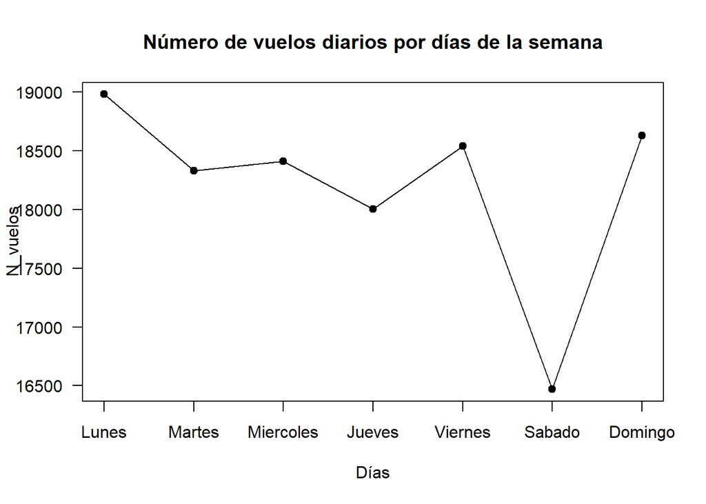

```r
plot(media_vuelos_por_dia_semana_1, type = "o", pch = 19, xaxt = "n", xlab = "Días", ylab = "N_vuelos", main = "Número de vuelos diarios por días de la semana", las = 2)
axis(1, at = 1:7, labels = c("Lunes", "Martes", "Miercoles", "Jueves", "Viernes","Sabado", "Domingo"))
```

```r
print(dias[vuelos2022[vuelos2022$DAY_OF_MONTH == 24 & vuelos2022$MONTH == 11, ]$DAY_OF_WEEK[1]])
```

```
## [1] "Jueves"
```

```r
vuelos_por_dia <- list()
V23E= vuelos2022[vuelos2022$MONTH==11,]
for (i in 1:nrow(V23E)) {
  dia <- V23E$DAY_OF_MONTH[i]
  mes <- 11
  año <- 2022
  fecha <- sprintf("%02d-%02d-%04d", dia, mes, año)
  if (fecha %in% names(vuelos_por_dia)) {
    vuelos_por_dia[[fecha]] <- vuelos_por_dia[[fecha]] + 1
  } else {
    vuelos_por_dia[[fecha]] <- 1
  }
}
V23E= vuelos2022[vuelos2022$MONTH==12,]
for (i in 1:nrow(V23E)) {
  dia <- V23E$DAY_OF_MONTH[i]
  mes <- 12
  año <- 2022
  fecha <- sprintf("%02d-%02d-%04d", dia, mes, año)
  if (fecha %in% names(vuelos_por_dia)) {
    vuelos_por_dia[[fecha]] <- vuelos_por_dia[[fecha]] + 1
  } else {
    vuelos_por_dia[[fecha]] <- 1
  }
}

vuelos_por_dia_df <- data.frame(Dia = as.Date(names(vuelos_por_dia),format = "%d-%m-%Y"), Num_Vuelos = unlist(vuelos_por_dia))

print(vuelos_por_dia_df)
```

```
##                   Dia Num_Vuelos
## 01-11-2022 2022-11-01      18743
## 02-11-2022 2022-11-02      18907
## 03-11-2022 2022-11-03      19655
## 04-11-2022 2022-11-04      18976
## 05-11-2022 2022-11-05      16109
## 06-11-2022 2022-11-06      19065
## 07-11-2022 2022-11-07      19139
## 08-11-2022 2022-11-08      18285
## 09-11-2022 2022-11-09      18084
## 10-11-2022 2022-11-10      18590
## 11-11-2022 2022-11-11      19326
## 12-11-2022 2022-11-12      17181
## 13-11-2022 2022-11-13      19646
## 14-11-2022 2022-11-14      19729
## 15-11-2022 2022-11-15      18762
## 16-11-2022 2022-11-16      18875
## 17-11-2022 2022-11-17      19668
## 18-11-2022 2022-11-18      19701
## 19-11-2022 2022-11-19      17591
## 20-11-2022 2022-11-20      19884
## 21-11-2022 2022-11-21      19818
## 22-11-2022 2022-11-22      19737
## 23-11-2022 2022-11-23      20060
## 24-11-2022 2022-11-24      12528
## 25-11-2022 2022-11-25      17331
## 26-11-2022 2022-11-26      18788
## 27-11-2022 2022-11-27      20339
## 28-11-2022 2022-11-28      20125
## 29-11-2022 2022-11-29      18609
## 30-11-2022 2022-11-30      17980
## 01-12-2022 2022-12-01      19067
## 02-12-2022 2022-12-02      19179
## 03-12-2022 2022-12-03      16742
## 04-12-2022 2022-12-04      19209
## 05-12-2022 2022-12-05      19329
## 06-12-2022 2022-12-06      18300
## 07-12-2022 2022-12-07      18449
## 08-12-2022 2022-12-08      19311
## 09-12-2022 2022-12-09      19348
## 10-12-2022 2022-12-10      16825
## 11-12-2022 2022-12-11      19087
## 12-12-2022 2022-12-12      19183
## 13-12-2022 2022-12-13      17896
## 14-12-2022 2022-12-14      18277
## 15-12-2022 2022-12-15      19323
## 16-12-2022 2022-12-16      19676
## 17-12-2022 2022-12-17      17674
## 18-12-2022 2022-12-18      19253
## 19-12-2022 2022-12-19      19318
## 20-12-2022 2022-12-20      18839
## 21-12-2022 2022-12-21      19090
## 22-12-2022 2022-12-22      17339
## 23-12-2022 2022-12-23      14413
## 24-12-2022 2022-12-24      12062
## 25-12-2022 2022-12-25      12559
## 26-12-2022 2022-12-26      15218
## 27-12-2022 2022-12-27      15827
## 28-12-2022 2022-12-28      15981
## 29-12-2022 2022-12-29      16577
## 30-12-2022 2022-12-30      18914
## 31-12-2022 2022-12-31      15256
```

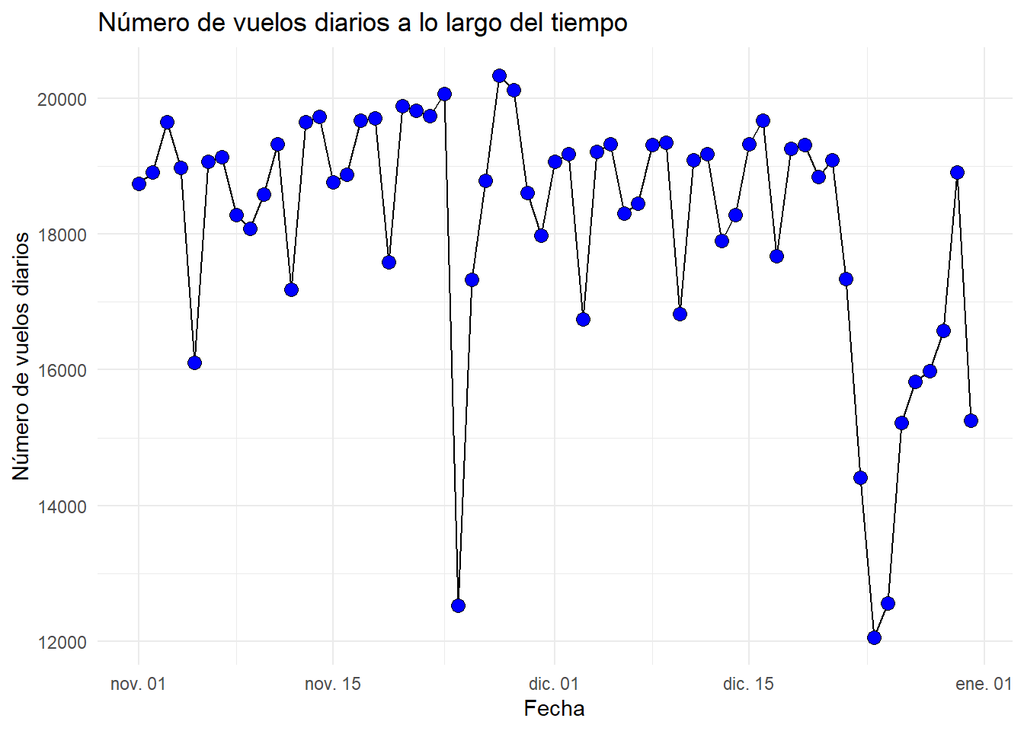

```r
ggplot(vuelos_por_dia_df, aes(x = Dia, y = Num_Vuelos)) +
  geom_line() +
  geom_point(shape = 21, size = 3, fill = "blue") +
  labs(x = "Fecha", y = "Número de vuelos diarios", title = "Número de vuelos diarios a lo largo del tiempo") +
  theme_minimal()
```

Observamos que sucede lo mismo que en el 2023, en día del festivo (en este caso es el 24 de Noviembre porque acción de gracias cambia de día cada año) la cantidad de vuelos baja drásticamente pero el día previo tiene un aumento de esta cifra con respecto a la media. En cambio podemos ver como la cantidad de vuelos los dos días siguientes a este festivo se ven afectadas también, lo que nos da a pensar que al ser una de las festividades más importante, o incluso la más importante en EEUU no sigue el comportamiento que habiamos estado viendo hasta el momento, sino que el día previo y dos, tres y cuatro días despues hay un aumento de vuelos (suponemos que por la cantidad de personas que los demandan) mientras eque el propio día y el siguiente hay una bajada considerable de esta cifra. Vamos a comprobar si esto es así viendo en 2021 y dariamos por finalizado el analisis de la influencia en la cantidad de vuelos los días festivos.

### 2.4.3 2021

```r
n_vuelos_20_nov=nrow(vuelos2021[vuelos2021$DAY_OF_MONTH==20 & vuelos2021$MONTH==11,])
n_vuelos_21_nov=nrow(vuelos2021[vuelos2021$DAY_OF_MONTH==21 & vuelos2021$MONTH==11,])
n_vuelos_22_nov=nrow(vuelos2021[vuelos2021$DAY_OF_MONTH==22 & vuelos2021$MONTH==11,])
n_vuelos_23_nov=nrow(vuelos2021[vuelos2021$DAY_OF_MONTH==23 & vuelos2021$MONTH==11,])
n_vuelos_24_nov=nrow(vuelos2021[vuelos2021$DAY_OF_MONTH==24 & vuelos2021$MONTH==11,])
n_vuelos_25_nov=nrow(vuelos2021[vuelos2021$DAY_OF_MONTH==25 & vuelos2021$MONTH==11,])
n_vuelos_26_nov=nrow(vuelos2021[vuelos2021$DAY_OF_MONTH==26 & vuelos2021$MONTH==11,])
n_vuelos_27_nov=nrow(vuelos2021[vuelos2021$DAY_OF_MONTH==27 & vuelos2021$MONTH==11,])
n_vuelos_28_nov=nrow(vuelos2021[vuelos2021$DAY_OF_MONTH==28 & vuelos2021$MONTH==11,])
n_vuelos_29_nov=nrow(vuelos2021[vuelos2021$DAY_OF_MONTH==29 & vuelos2021$MONTH==11,])
n_vuelos_30_nov=nrow(vuelos2021[vuelos2021$DAY_OF_MONTH==30 & vuelos2021$MONTH==11,])

n_vuelos= c(n_vuelos_20_nov, n_vuelos_21_nov, n_vuelos_22_nov, n_vuelos_23_nov, n_vuelos_24_nov, n_vuelos_25_nov, n_vuelos_26_nov, n_vuelos_27_nov, n_vuelos_28_nov, n_vuelos_29_nov, n_vuelos_30_nov)
```

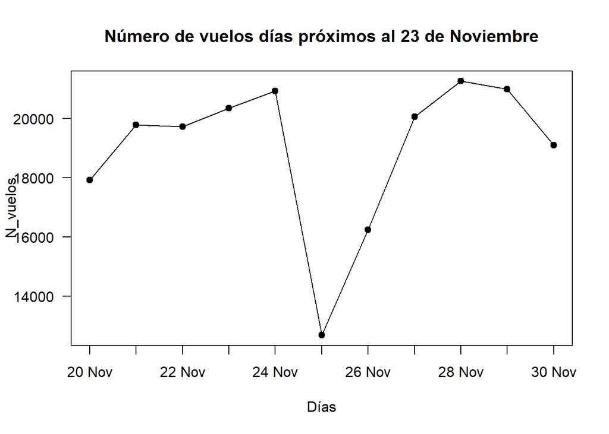

```r
plot(n_vuelos, type = "o", pch = 19, xaxt = "n", xlab = "Días", ylab = "N_vuelos", main = "Número de vuelos días próximos al 23 de Noviembre", las = 2)
axis(1, at = 1:11, labels = c("20 Nov", "21 Nov", "22 Nov","23 Nov", "24 Nov", "25 Nov", "26 Nov", "27 Nov", "28 Nov", "29 Nov", "30 Nov"))
```

```r
media_vuelos_por_dia_semana <- rep(0, 7)

M <- vuelos2021[vuelos2021$MONTH == 11, ]
dias <- c("Lunes", "Martes", "Miercoles", "Jueves", "Viernes", "Sabado", "Domingo")
cant_dias <- setNames(rep(0, length(dias)), dias)
añadidos <- list()
for (i in 1:nrow(M)) {
  dia_sem <- dias[M$DAY_OF_WEEK[i]]
  media_vuelos_por_dia_semana[M$DAY_OF_WEEK[i]] <- media_vuelos_por_dia_semana[M$DAY_OF_WEEK[i]] + 1
  fecha <- sprintf("%02d-%02d-%04d", M$DAY_OF_MONTH[i], 11, 2021)
  if (fecha %in% names(añadidos)) {
  } else {
    añadidos[[fecha]] <- 1
    cant_dias[dias[M$DAY_OF_WEEK[i]]] <- cant_dias[dias[M$DAY_OF_WEEK[i]]] + 1
  }
}
M <- vuelos2021[vuelos2021$MONTH == 12, ]
for (i in 1:nrow(M)) {
  dia_sem <- dias[M$DAY_OF_WEEK[i]]
  media_vuelos_por_dia_semana[M$DAY_OF_WEEK[i]] <- media_vuelos_por_dia_semana[M$DAY_OF_WEEK[i]] + 1
  fecha <- sprintf("%02d-%02d-%04d", M$DAY_OF_MONTH[i], 12, 2021)
  if (fecha %in% names(añadidos)) {
  } else {
    añadidos[[fecha]] <- 1
    cant_dias[dias[M$DAY_OF_WEEK[i]]] <- cant_dias[dias[M$DAY_OF_WEEK[i]]] + 1
  }
}

media_vuelos_por_dia_semana_1 <- rep(0, 7)
for (i in 1:7){
  media_vuelos_por_dia_semana_1[i] <- media_vuelos_por_dia_semana[i]/cant_dias[dias[i]]
}

media_vuelos_por_dia_semana_df <- data.frame(Dia_sem = dias, Num_Vuelos = media_vuelos_por_dia_semana_1)

print(media_vuelos_por_dia_semana_df)
```

```
##     Dia_sem Num_Vuelos
## 1     Lunes   19605.44
## 2    Martes   18298.33
## 3 Miercoles   18719.33
## 4    Jueves   18986.33
## 5   Viernes   18514.00
## 6    Sabado   17109.62
## 7   Domingo   19507.00
```

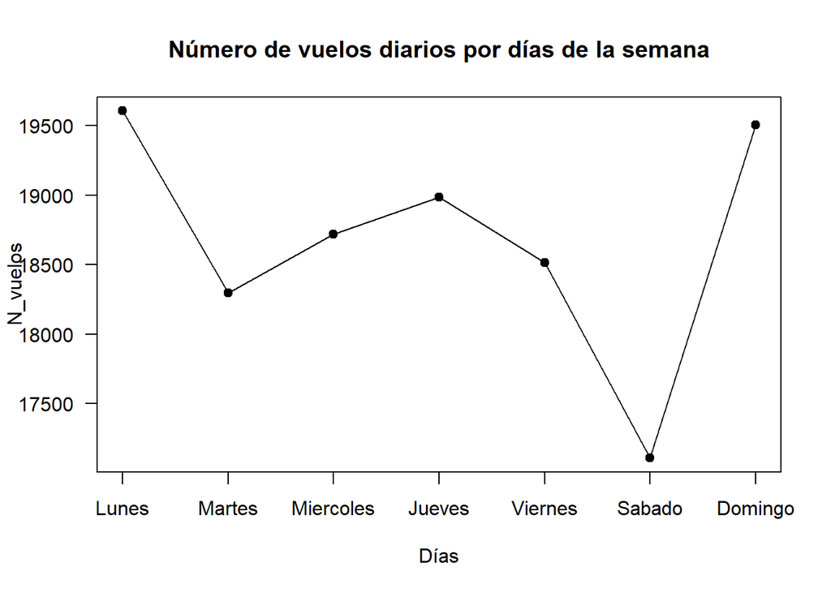

```r
plot(media_vuelos_por_dia_semana_1, type = "o", pch = 19, xaxt = "n", xlab = "Días", ylab = "N_vuelos", main = "Número de vuelos diarios por días de la semana", las = 2)
axis(1, at = 1:7, labels = c("Lunes", "Martes", "Miercoles", "Jueves", "Viernes","Sabado", "Domingo"))
```

```r
print(dias[vuelos2021[vuelos2021$DAY_OF_MONTH == 25 & vuelos2021$MONTH == 11, ]$DAY_OF_WEEK[1]])
```

```
## [1] "Jueves"
```

```r
vuelos_por_dia <- list()
V23E= vuelos2021[vuelos2021$MONTH==11,]
for (i in 1:nrow(V23E)) {
  dia <- V23E$DAY_OF_MONTH[i]
  mes <- 11
  año <- 2021
  fecha <- sprintf("%02d-%02d-%04d", dia, mes, año)
  if (fecha %in% names(vuelos_por_dia)) {
    vuelos_por_dia[[fecha]] <- vuelos_por_dia[[fecha]] + 1
  } else {
    vuelos_por_dia[[fecha]] <- 1
  }
}
V23E= vuelos2021[vuelos2021$MONTH==12,]
for (i in 1:nrow(V23E)) {
  dia <- V23E$DAY_OF_MONTH[i]
  mes <- 12
  año <- 2021
  fecha <- sprintf("%02d-%02d-%04d", dia, mes, año)
  if (fecha %in% names(vuelos_por_dia)) {
    vuelos_por_dia[[fecha]] <- vuelos_por_dia[[fecha]] + 1
  } else {
    vuelos_por_dia[[fecha]] <- 1
  }
}

vuelos_por_dia_df <- data.frame(Dia = as.Date(names(vuelos_por_dia),format = "%d-%m-%Y"), Num_Vuelos = unlist(vuelos_por_dia))

print(vuelos_por_dia_df)
```

```
##                   Dia Num_Vuelos
## 01-11-2021 2021-11-01      19389
## 02-11-2021 2021-11-02      17911
## 03-11-2021 2021-11-03      18776
## 04-11-2021 2021-11-04      20424
## 05-11-2021 2021-11-05      20346
## 06-11-2021 2021-11-06      17184
## 07-11-2021 2021-11-07      19620
## 08-11-2021 2021-11-08      19973
## 09-11-2021 2021-11-09      17835
## 10-11-2021 2021-11-10      18416
## 11-11-2021 2021-11-11      20241
## 12-11-2021 2021-11-12      20152
## 13-11-2021 2021-11-13      16806
## 14-11-2021 2021-11-14      19667
## 15-11-2021 2021-11-15      20053
## 16-11-2021 2021-11-16      17814
## 17-11-2021 2021-11-17      18674
## 18-11-2021 2021-11-18      20394
## 19-11-2021 2021-11-19      20494
## 20-11-2021 2021-11-20      17934
## 21-11-2021 2021-11-21      19785
## 22-11-2021 2021-11-22      19735
## 23-11-2021 2021-11-23      20354
## 24-11-2021 2021-11-24      20935
## 25-11-2021 2021-11-25      12688
## 26-11-2021 2021-11-26      16242
## 27-11-2021 2021-11-27      20067
## 28-11-2021 2021-11-28      21267
## 29-11-2021 2021-11-29      20996
## 30-11-2021 2021-11-30      19098
## 01-12-2021 2021-12-01      18393
## 02-12-2021 2021-12-02      19800
## 03-12-2021 2021-12-03      19792
## 04-12-2021 2021-12-04      16376
## 05-12-2021 2021-12-05      19341
## 06-12-2021 2021-12-06      19149
## 07-12-2021 2021-12-07      17255
## 08-12-2021 2021-12-08      17886
## 09-12-2021 2021-12-09      19521
## 10-12-2021 2021-12-10      19229
## 11-12-2021 2021-12-11      16067
## 12-12-2021 2021-12-12      19241
## 13-12-2021 2021-12-13      19215
## 14-12-2021 2021-12-14      17145
## 15-12-2021 2021-12-15      17420
## 16-12-2021 2021-12-16      19554
## 17-12-2021 2021-12-17      19966
## 18-12-2021 2021-12-18      17680
## 19-12-2021 2021-12-19      19104
## 20-12-2021 2021-12-20      19714
## 21-12-2021 2021-12-21      19335
## 22-12-2021 2021-12-22      19600
## 23-12-2021 2021-12-23      20006
## 24-12-2021 2021-12-24      15653
## 25-12-2021 2021-12-25      14763
## 26-12-2021 2021-12-26      18031
## 27-12-2021 2021-12-27      18225
## 28-12-2021 2021-12-28      17938
## 29-12-2021 2021-12-29      18374
## 30-12-2021 2021-12-30      18249
## 31-12-2021 2021-12-31      14752
```

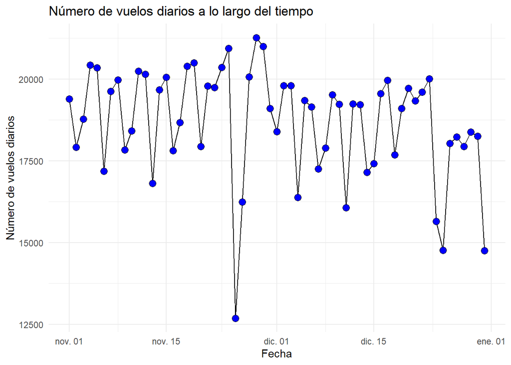

```r
ggplot(vuelos_por_dia_df, aes(x = Dia, y = Num_Vuelos)) +
  geom_line() +
  geom_point(shape = 21, size = 3, fill = "blue") +
  labs(x = "Fecha", y = "Número de vuelos diarios", title = "Número de vuelos diarios a lo largo del tiempo") +
  theme_minimal()
```

# 3 Conclusiones de la cantidad de vuelos los días festivos

Tras hacer de nuevo los mismos pasos observamos que se repite exactamente igual lo que habiamos observado anteriorme, el aumento el día previo, dos, tres y cuatro días después y el descenso del propio día del festivo y el siguiente.

# 4 Retrasos los días festivos

## 4.1 Medias de retrasos por días y meses los 3 años estudiados

```r
vuelos_repe <- vuelos
vuelos_repe$MONTH <- factor(vuelos_repe$MONTH, levels = 1:12, labels = month.abb)
media_retraso_por_mes2023 <- vuelos_repe %>%
  group_by(MONTH) %>%
  summarise(media_retraso = mean(salida_retraso))
print(media_retraso_por_mes2023)
```

```
## # A tibble: 12 × 2
##    MONTH media_retraso
##    <fct>         <dbl>
##  1 Jan           16.2
##  2 Feb           13.6
##  3 Mar           15.8
##  4 Apr           16.7
##  5 May           13.3
##  6 Jun           21.2
##  7 Jul           23.5
##  8 Aug           17.1
##  9 Sep           14.1
## 10 Oct           11.0
## 11 Nov            9.47
## 12 Dec           11.7
```

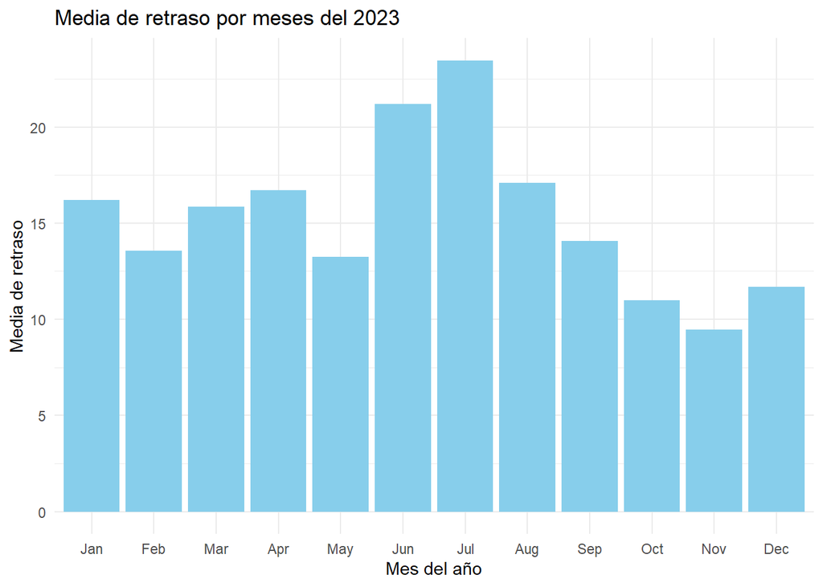

```r
ggplot(media_retraso_por_mes2023, aes(x = MONTH, y = media_retraso)) +
  geom_bar(stat = "identity", fill = "skyblue") +
  labs(title = "Media de retraso por meses del 2023",
       x = "Mes del año",
       y = "Media de retraso") +
  theme_minimal()
```

```r
get_weekday_name <- function(weekday_num) {
  weekdays <- c("Lunes", "Martes", "Miércoles", "Jueves", "Viernes", "Sábado", "Domingo")
  return(weekdays[weekday_num])
}

media_retraso_por_dia2023 <- vuelos_repe %>%
  group_by(WEEKDAY_NAME = get_weekday_name(DAY_OF_WEEK)) %>%
  summarise(media_retraso = mean(salida_retraso))
media_retraso_por_dia2023$WEEKDAY_NAME <- factor(media_retraso_por_dia2023$WEEKDAY_NAME, levels = c("Lunes", "Martes", "Miércoles", "Jueves", "Viernes", "Sábado", "Domingo"))
print(media_retraso_por_dia2023)
```

```
## # A tibble: 7 × 2
##   WEEKDAY_NAME media_retraso
##   <fct>                <dbl>
## 1 Domingo               17.3
## 2 Jueves                15.2
## 3 Lunes                 15.4
## 4 Martes                12.9
## 5 Miércoles             14.3
## 6 Sábado                15.6
## 7 Viernes               16.4
```

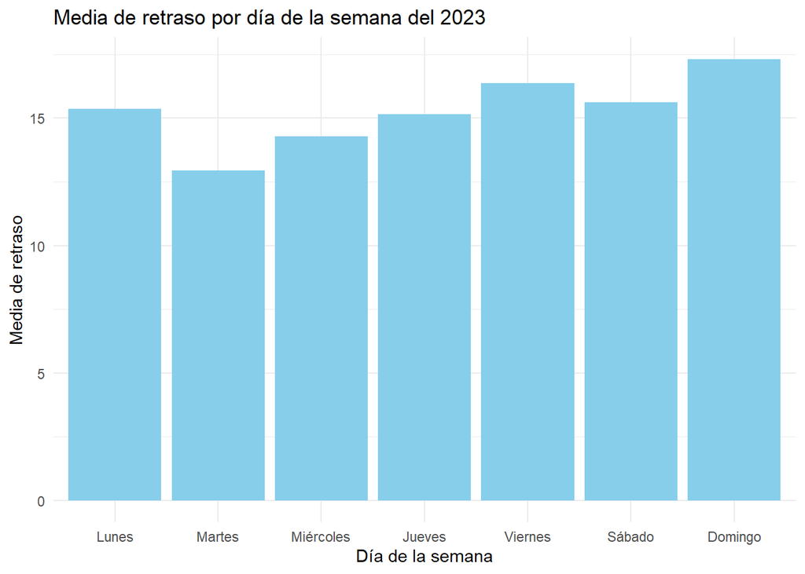

```r
ggplot(media_retraso_por_dia2023, aes(x = WEEKDAY_NAME, y = media_retraso)) +
  geom_bar(stat = "identity", fill = "skyblue") +
  labs(title = "Media de retraso por día de la semana del 2023",
       x = "Día de la semana",
       y = "Media de retraso") +
  theme_minimal()
```

```r
vuelos2022_repe <- vuelos2022
vuelos2022_repe$MONTH <- factor(vuelos2022_repe$MONTH, levels = 1:12, labels = month.abb)
media_retraso_por_mes2022 <- vuelos2022_repe %>%
  group_by(MONTH) %>%
  summarise(media_retraso = mean(salida_retraso))
print(media_retraso_por_mes2022)
```

```
## # A tibble: 12 × 2
##    MONTH media_retraso
##    <fct>         <dbl>
##  1 Jan            14.6
##  2 Feb            14.4
##  3 Mar            15.3
##  4 Apr            16.1
##  5 May            15.3
##  6 Jun            18.3
##  7 Jul            17.7
##  8 Aug            16.9
##  9 Sep            11.7
## 10 Oct            11.3
## 11 Nov            13.1
## 12 Dec            20.9
```

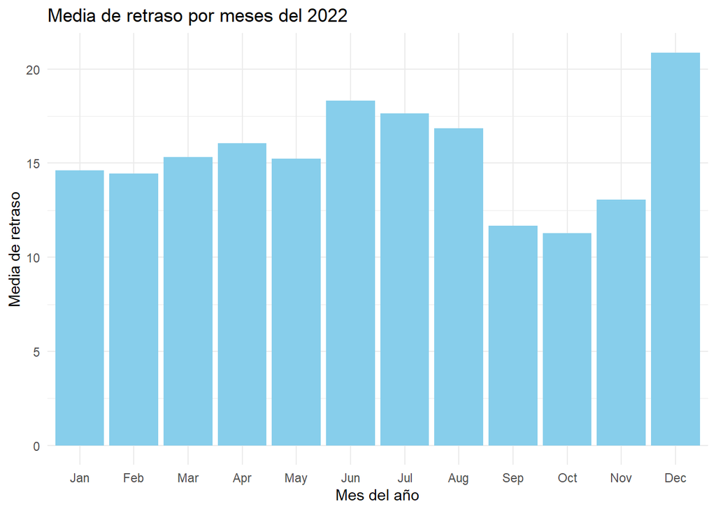

```r
ggplot(media_retraso_por_mes2022, aes(x = MONTH, y = media_retraso)) +
  geom_bar(stat = "identity", fill = "skyblue") +
  labs(title = "Media de retraso por meses del 2022",
       x = "Mes del año",
       y = "Media de retraso") +
  theme_minimal()
```